# Multivariante

Eduardo Montoro de la Cruz

2024-11-22

```r
library(summarytools)
library(ggpubr)
```

```r
library(ggplot2)
library(factoextra)
library(scatterplot3d)
library(foreign)
# Package required to call 'scatterplot3d' function
library(scatterplot3d)
# Package required to call 'melt' function
library(reshape2)
# Package required to call 'mvn' function
library(MVN)
# Package required to call 'boxM' function
library(biotools)
# Package required to call 'partimat' function
library(klaR)
# Package required to call 'summarise' function
library(dplyr)
# Package required to call 'createDataPartition' function
library(caret)
primaria<-read.spss("Burnout_EBAP_20_22_IJERPH.sav", to.data.frame=TRUE)
```

```
## re-encoding from CP1252
```

```r
#gestoras<-read.spss("Burnout_gestoras_15_22_JPM.sav", to.data.frame=TRUE)
```

```r
#primaria<-primaria[,-c(27,29,30)] #Eliminamos las columnas con muchos NAN y servicio2, que no aporta.
primaria<-primaria[,-25]
#Eliminamos la columna de Pacientes de 60 años por tener todo NA

primaria<-primaria[,-28]

#Eliminamos las columnas relacionadas con las preguntas.

primaria<-primaria[,1:28]



#Hacemos factores las columnas

primaria[, c("MBI_CE_Cat", "MBI_D_Cat","MBI_RP_Cat","Sexo","Servicio","Turno_Cat","Guardias","Puesto_trabajo","Estado_Civil_Cat","Num_hijos_Cat","Categoría","Provincia","Estado_Civil","Turno","Nombre","Gestíon","Ocupó_gestión")] <- lapply(primaria[, c("MBI_CE_Cat", "MBI_D_Cat","MBI_RP_Cat","Sexo","Servicio","Turno_Cat","Guardias","Puesto_trabajo","Estado_Civil_Cat","Num_hijos_Cat","Categoría","Provincia","Estado_Civil","Turno","Nombre","Gestíon","Ocupó_gestión")], as.factor)
```

```r
#Codificamos todo
#Para las respuestas Bajo medio alto se asigna el 1,2,3.
cols_MBI=c("MBI_CE_Cat", "MBI_D_Cat","MBI_RP_Cat")
primaria[,cols_MBI]<-lapply(primaria[,cols_MBI],factor,level=c("Bajo","Medio","Alto"),labels=c(1,2,3))

#Para el numero de hijos asigno cada numero segun el numero de hijos

primaria$Num_hijos_Cat<-factor(primaria$Num_hijos_Cat,level=c("Sin hijos","Un hijo","Dos hijos","Familia Numerosa"),labels=c(0,1,2,3))

#Para las columnas con respuestas Hombre/Mujer, Casado/soltero, etc se asignan los numeros de menor a mayor por orden alfabetico.

primaria$Sexo<-factor(primaria$Sexo,level=c("Hombre","Mujer"),labels=c(1,2))

primaria$Servicio<-factor(primaria$Servicio,levels=sort(levels(primaria$Servicio)))

primaria$Turno_Cat<-factor(primaria$Turno_Cat,levels=sort(levels(primaria$Turno_Cat)))

primaria$Guardias<-factor(primaria$Guardias,levels=sort(levels(primaria$Guardias)))

primaria$Puesto_trabajo<-factor(primaria$Puesto_trabajo,levels=sort(levels(primaria$Puesto_trabajo)))

primaria$Estado_Civil_Cat<-factor(primaria$Estado_Civil_Cat,levels=sort(levels(primaria$Estado_Civil_Cat)))

primaria$Num_hijos_Cat<-factor(primaria$Num_hijos_Cat,levels=sort(levels(primaria$Num_hijos_Cat)))

primaria$Categoría<-factor(primaria$Categoría,levels=sort(levels(primaria$Categoría)))

primaria$Provincia<-factor(primaria$Provincia,levels=sort(levels(primaria$Provincia)))

primaria$Estado_Civil<-factor(primaria$Estado_Civil,levels=sort(levels(primaria$Estado_Civil)))

primaria$Turno<-factor(primaria$Turno,levels=sort(levels(primaria$Turno)))

primaria$Nombre<-factor(primaria$Nombre,levels=sort(levels(primaria$Nombre)))

primaria$Gestíon<-factor(primaria$Gestíon, levels=sort(levels(primaria$Gestíon)))

primaria$Ocupó_gestión<-factor(primaria$Ocupó_gestión, levels=sort(levels(primaria$Ocupó_gestión)))
```

```r
# Funcion para arreglar los datos NA de tiempo de gestion en concreto
not_available_tiempogestion<-function(data,na.rm=F){
data[is.na(data)]<- 0
data
}
# Funcion por si alguien NA en gestion o ocupo gestion
not_available_gestion<-function(data,na.rm=F){
data[is.na(data)]<- 'No' #¿Aqui por que no funciona si pongo la mode(data) o median(data)??
data
}


moda <- function(x) {
  ux <- unique(na.omit(x))  # Valores únicos, eliminando NA
  ux[which.max(tabulate(match(x, ux)))]  # El valor con mayor frecuencia
}

not_available_hijos <- function(data) {
  moda_valor <- moda(data)  # Calculamos la moda
  data[is.na(data)] <- moda_valor  # Reemplazamos NA con la moda
  return(data)  # Devolvemos la columna modificada
}
primaria$Num_hijos_Cat <- not_available_hijos(primaria$Num_hijos_Cat)
primaria$Numero_hijos <- not_available_hijos(primaria$Numero_hijos)


cols_tgestion<-c('Tiempo_gestión','Tiempo_ocupó_gestión')
cols_gestion<-c('Gestíon','Ocupó_gestión')
#primaria[,cols_gestion]

#Ahora tocaria aplicar estas funciones a las columnas adecuadas

primaria[,cols_tgestion]<-lapply(primaria[,cols_tgestion],not_available_tiempogestion)
primaria[,cols_gestion]<-lapply(primaria[,cols_gestion],not_available_gestion)

#Ahora cambiar los valores no nulos que hayan puesto que no, en un Si
primaria[primaria$Tiempo_gestión!=0,'Gestíon'] <-'Sí'

#primaria[,c(cols_gestion,cols_tgestion)]
```

Estudiamos graficas varias de distintas variables. Empezamos por las variables cuantitativas

```r
#Variables cuantitativas

descr(primaria$Neur_NEOFFI)
```

```
## Descriptive Statistics
## primaria$Neur_NEOFFI
## N: 258
##
##                     Neur_NEOFFI
## ----------------- -------------
##              Mean         28.26
##           Std.Dev          8.20
##               Min         12.00
##                Q1         22.00
##            Median         28.00
##                Q3         34.00
##               Max         53.00
##               MAD          8.90
##               IQR         11.75
##                CV          0.29
##          Skewness          0.35
##       SE.Skewness          0.15
##          Kurtosis         -0.14
##           N.Valid        258.00
##         Pct.Valid        100.00
```

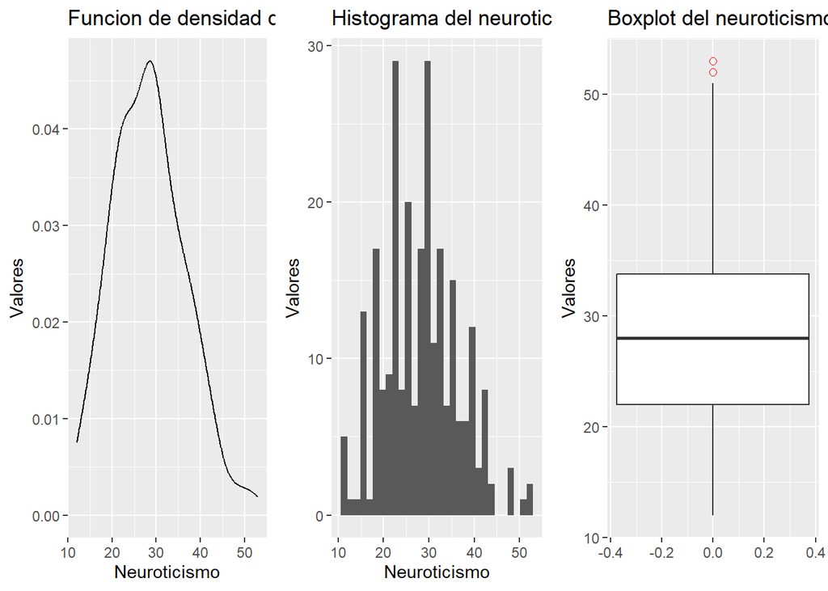

```r
p1<-ggplot(primaria,aes(x=Neur_NEOFFI))+geom_density()+
labs(title = "Funcion de densidad del neuroticismo",x="Neuroticismo",y="Valores")
p2<-ggplot(primaria,aes(x=Neur_NEOFFI))+geom_histogram()+
labs(title = "Histograma del neuroticismo",x="Neuroticismo",y="Valores")
p3<-ggplot(primaria,aes(x=Neur_NEOFFI))+
geom_boxplot(outlier.colour="red", outlier.shape=1,outlier.size=2)+
coord_flip()+labs(title = "Boxplot del neuroticismo",x="Valores",y="")

ggarrange(p1,p2,p3, nrow=1, common.legend = FALSE)
```

```r
descr(primaria$Amab_NEOFFI)
```

```
## Descriptive Statistics
## primaria$Amab_NEOFFI
## N: 258
##
##                     Amab_NEOFFI
## ----------------- -------------
##              Mean         44.72
##           Std.Dev          7.65
##               Min         19.00
##                Q1         40.00
##            Median         45.00
##                Q3         50.00
##               Max         60.00
##               MAD          7.41
##               IQR         10.00
##                CV          0.17
##          Skewness         -0.48
##       SE.Skewness          0.15
##          Kurtosis          0.10
##           N.Valid        258.00
##         Pct.Valid        100.00
```

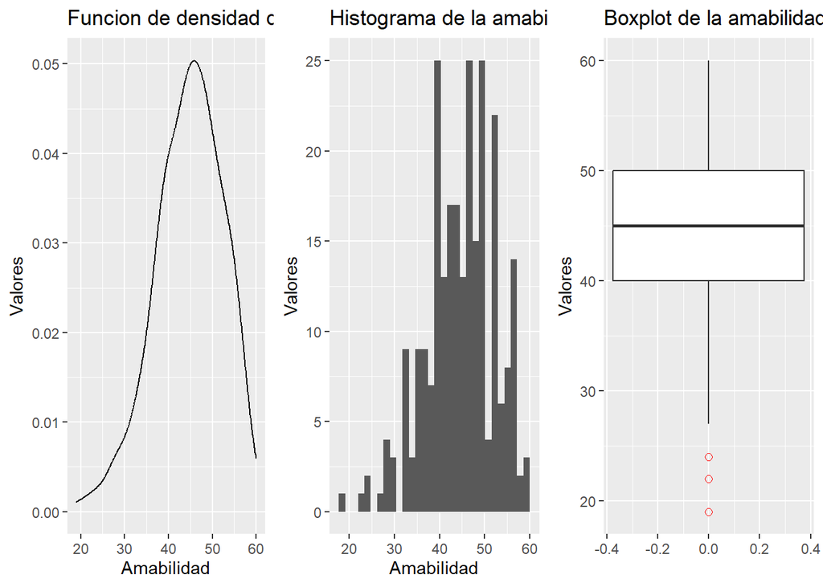

```r
p1<-ggplot(primaria,aes(x=Amab_NEOFFI))+geom_density()+
labs(title = "Funcion de densidad de la amabilidad",x="Amabilidad",y="Valores")
p2<-ggplot(primaria,aes(x=Amab_NEOFFI))+geom_histogram()+
labs(title = "Histograma de la amabilidad",x="Amabilidad",y="Valores")
p3<-ggplot(primaria,aes(x=Amab_NEOFFI))+
geom_boxplot(outlier.colour="red", outlier.shape=1,outlier.size=2)+
coord_flip()+labs(title = "Boxplot de la amabilidad",x="Valores",y="")

ggarrange(p1,p2,p3, nrow=1, common.legend = FALSE)
```

```r
descr(primaria$Resp_NEOFFI)
```

```
## Descriptive Statistics
## primaria$Resp_NEOFFI
## N: 258
##
##                     Resp_NEOFFI
## ----------------- -------------
##              Mean         46.60
##           Std.Dev          7.22
##               Min         20.00
##                Q1         42.00
##            Median         47.00
##                Q3         52.00
##               Max         60.00
##               MAD          7.41
##               IQR         10.00
##                CV          0.15
##          Skewness         -0.49
##       SE.Skewness          0.15
##          Kurtosis          0.37
##           N.Valid        258.00
##         Pct.Valid        100.00
```

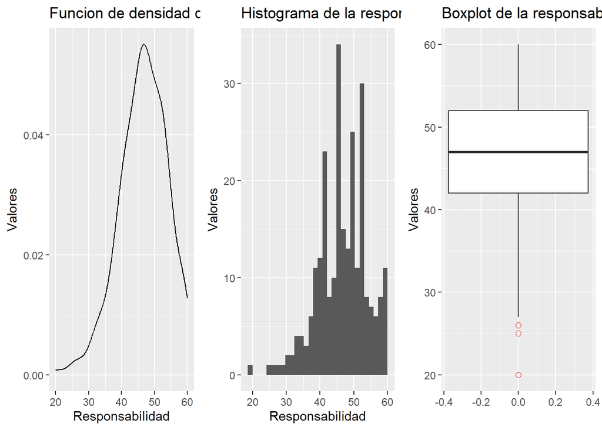

```r
p1<-ggplot(primaria,aes(x=Resp_NEOFFI))+geom_density()+
labs(title = "Funcion de densidad de la responsabilidad",x="Responsabilidad",y="Valores")
p2<-ggplot(primaria,aes(x=Resp_NEOFFI))+geom_histogram()+
labs(title = "Histograma de la responsabilidad",x="Responsabilidad",y="Valores")
p3<-ggplot(primaria,aes(x=Resp_NEOFFI))+
geom_boxplot(outlier.colour="red", outlier.shape=1,outlier.size=2)+
coord_flip()+labs(title = "Boxplot de la responsabilidad",x="Valores",y="")

ggarrange(p1,p2,p3, nrow=1, common.legend = FALSE)
```

```r
descr(primaria$Extrav_NEOFFI)
```

```
## Descriptive Statistics
## primaria$Extrav_NEOFFI
## N: 258
##
##                     Extrav_NEOFFI
## ----------------- ---------------
##              Mean           42.01
##           Std.Dev            7.88
##               Min           20.00
##                Q1           36.00
##            Median           42.00
##                Q3           47.00
##               Max           58.00
##               MAD            7.41
##               IQR           10.75
##                CV            0.19
##          Skewness           -0.16
##       SE.Skewness            0.15
##          Kurtosis           -0.26
##           N.Valid          258.00
##         Pct.Valid          100.00
```

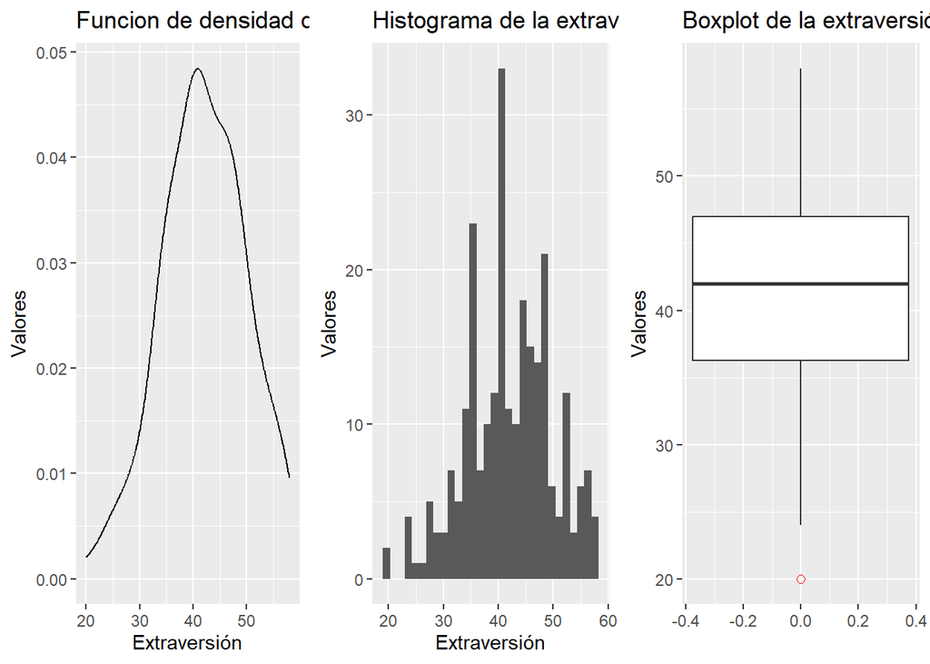

```r
p1<-ggplot(primaria,aes(x=Extrav_NEOFFI))+geom_density()+
labs(title = "Funcion de densidad de la extraversión",x="Extraversión",y="Valores")
p2<-ggplot(primaria,aes(x=Extrav_NEOFFI))+geom_histogram()+
labs(title = "Histograma de la extraversión",x="Extraversión",y="Valores")
p3<-ggplot(primaria,aes(x=Extrav_NEOFFI))+
geom_boxplot(outlier.colour="red", outlier.shape=1,outlier.size=2)+
coord_flip()+labs(title = "Boxplot de la extraversión",x="Valores",y="")

ggarrange(p1,p2,p3, nrow=1, common.legend = FALSE)
```

```r
descr(primaria$Apert_NEOFFI)
```

```
## Descriptive Statistics
## primaria$Apert_NEOFFI
## N: 258
##
##                     Apert_NEOFFI
## ----------------- --------------
##              Mean          39.08
##           Std.Dev           6.72
##               Min          20.00
##                Q1          34.00
##            Median          39.00
##                Q3          43.00
##               Max          57.00
##               MAD           7.41
##               IQR           9.00
##                CV           0.17
##          Skewness           0.06
##       SE.Skewness           0.15
##          Kurtosis           0.04
##           N.Valid         258.00
##         Pct.Valid         100.00
```

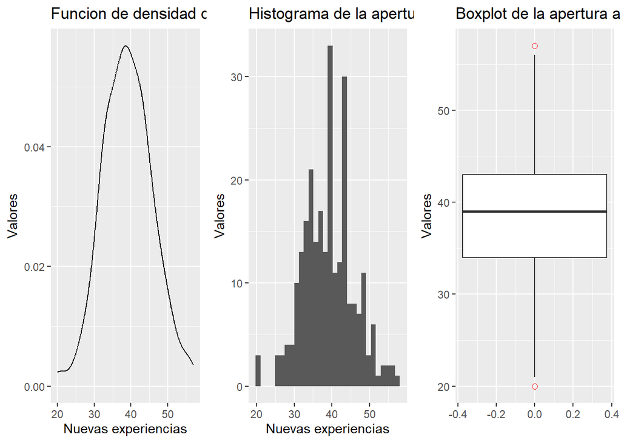

```r
p1<-ggplot(primaria,aes(x=Apert_NEOFFI))+geom_density()+
labs(title = "Funcion de densidad de la apertura a nuevas experiencias",x="Nuevas experiencias",y="Valores")
p2<-ggplot(primaria,aes(x=Apert_NEOFFI))+geom_histogram()+
labs(title = "Histograma de la apertura a nuevas experiencias",x="Nuevas experiencias",y="Valores")
p3<-ggplot(primaria,aes(x=Apert_NEOFFI))+
geom_boxplot(outlier.colour="red", outlier.shape=1,outlier.size=2)+
coord_flip()+labs(title = "Boxplot de la apertura a nuevas experiencias",x="Valores",y="")

ggarrange(p1,p2,p3, nrow=1, common.legend = FALSE)
```

Vamos ahora a por las cualitativas

```r
primaria$MBI_CE_Cat <- factor(primaria$MBI_CE_Cat,levels=c(1,2,3),labels=c("Bajo","Medio","Alto"))
freq(primaria$MBI_CE_Cat)
```

```
## Frequencies
## primaria$MBI_CE_Cat
## Type: Factor
##
##               Freq   % Valid   % Valid Cum.   % Total   % Total Cum.
## ----------- ------ --------- -------------- --------- --------------
##        Bajo    118     45.74          45.74     45.74          45.74
##       Medio     64     24.81          70.54     24.81          70.54
##        Alto     76     29.46         100.00     29.46         100.00
##        <NA>      0                               0.00         100.00
##       Total    258    100.00         100.00    100.00         100.00
```

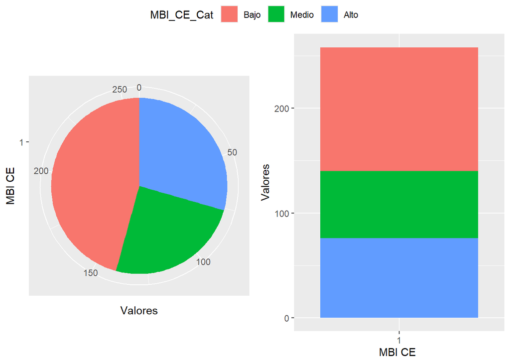

```r
p1<-ggplot(primaria,aes(x=factor(1),fill=MBI_CE_Cat))+geom_bar()+
coord_polar("y")+labs(x="MBI CE",y="Valores")
p2<-ggplot(primaria,aes(x=factor(1),fill=MBI_CE_Cat))+geom_bar()+
labs(x="MBI CE ",y="Valores")
ggarrange(p1,p2,nrow = 1,ncol=2, common.legend = TRUE)
```

```r
primaria$MBI_D_Cat <- factor(primaria$MBI_D_Cat,levels=c(1,2,3),labels=c("Bajo","Medio","Alto"))
freq(primaria$MBI_D_Cat)
```

```
## Frequencies
## primaria$MBI_D_Cat
## Type: Factor
##
##               Freq   % Valid   % Valid Cum.   % Total   % Total Cum.
## ----------- ------ --------- -------------- --------- --------------
##        Bajo     87     33.72          33.72     33.72          33.72
##       Medio     73     28.29          62.02     28.29          62.02
##        Alto     98     37.98         100.00     37.98         100.00
##        <NA>      0                               0.00         100.00
##       Total    258    100.00         100.00    100.00         100.00
```

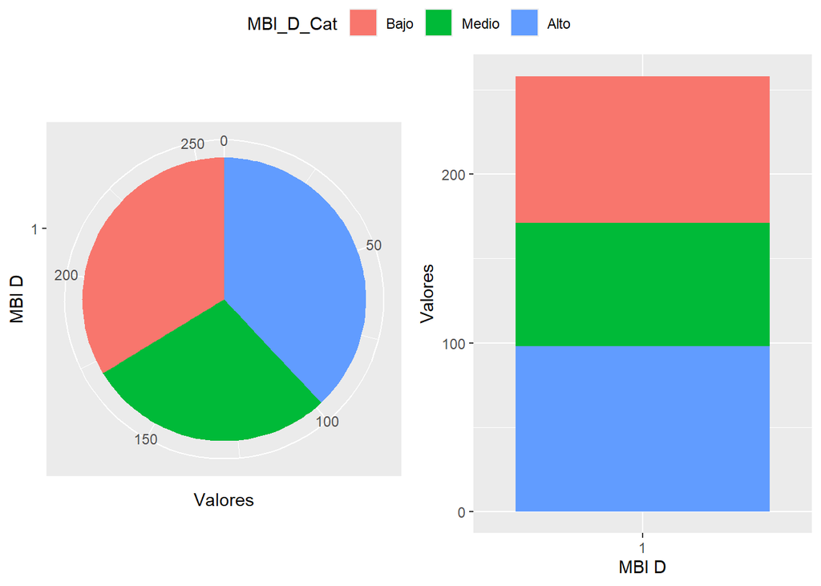

```r
p1<-ggplot(primaria,aes(x=factor(1),fill=MBI_D_Cat))+geom_bar()+
coord_polar("y")+labs(x="MBI D",y="Valores")
p2<-ggplot(primaria,aes(x=factor(1),fill=MBI_D_Cat))+geom_bar()+
labs(x="MBI D",y="Valores")
ggarrange(p1,p2,nrow = 1,ncol=2, common.legend = TRUE)
```

```r
primaria$MBI_RP_Cat <- factor(primaria$MBI_RP_Cat,levels=c(1,2,3),labels=c("Bajo","Medio","Alto"))
freq(primaria$MBI_RP_Cat)
```

```
## Frequencies
## primaria$MBI_RP_Cat
## Type: Factor
##
##               Freq   % Valid   % Valid Cum.   % Total   % Total Cum.
## ----------- ------ --------- -------------- --------- --------------
##        Bajo    105     40.70          40.70     40.70          40.70
##       Medio     78     30.23          70.93     30.23          70.93
##        Alto     75     29.07         100.00     29.07         100.00
##        <NA>      0                               0.00         100.00
##       Total    258    100.00         100.00    100.00         100.00
```

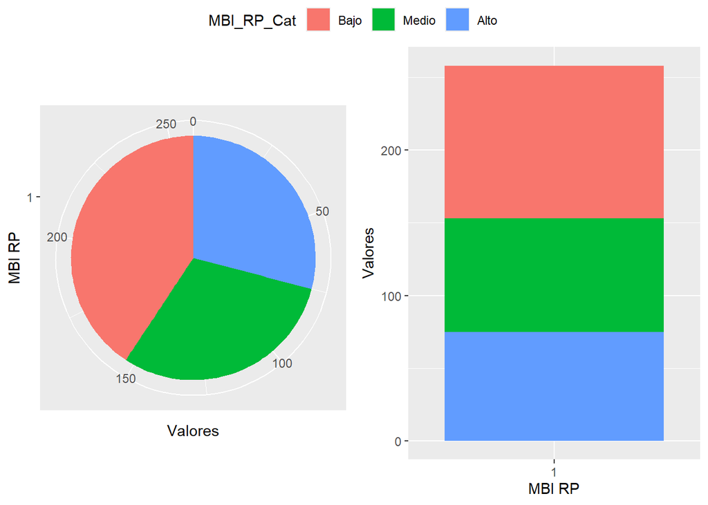

```r
p1<-ggplot(primaria,aes(x=factor(1),fill=MBI_RP_Cat))+geom_bar()+
coord_polar("y")+labs(x="MBI RP",y="Valores")
p2<-ggplot(primaria,aes(x=factor(1),fill=MBI_RP_Cat))+geom_bar()+
labs(x="MBI RP",y="Valores")
ggarrange(p1,p2,nrow = 1,ncol=2, common.legend = TRUE)
```

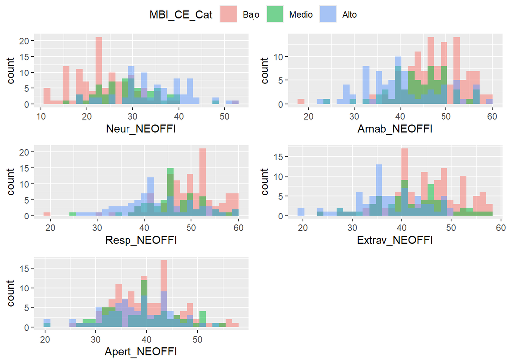

```r
attach(primaria)
#Primero para MBI CE
p1 <- ggplot(data = primaria, aes(x = Neur_NEOFFI, fill = MBI_CE_Cat)) +
geom_histogram(position = "identity", alpha = 0.5)
p2 <- ggplot(data = primaria, aes(x = Amab_NEOFFI, fill = MBI_CE_Cat)) +
geom_histogram(position = "identity", alpha = 0.5)
p3 <- ggplot(data = primaria, aes(x = Resp_NEOFFI, fill = MBI_CE_Cat)) +
geom_histogram(position = "identity", alpha = 0.5)
p4 <- ggplot(data = primaria, aes(x = Extrav_NEOFFI, fill = MBI_CE_Cat)) +
geom_histogram(position = "identity", alpha = 0.5)
p5 <- ggplot(data = primaria, aes(x = Apert_NEOFFI, fill = MBI_CE_Cat)) +
geom_histogram(position = "identity", alpha = 0.5)

ggarrange(p1, p2, p3,p4,p5, nrow = 3,ncol = 2, common.legend = TRUE, top = "Clas. individual según el MBI_CE")
```

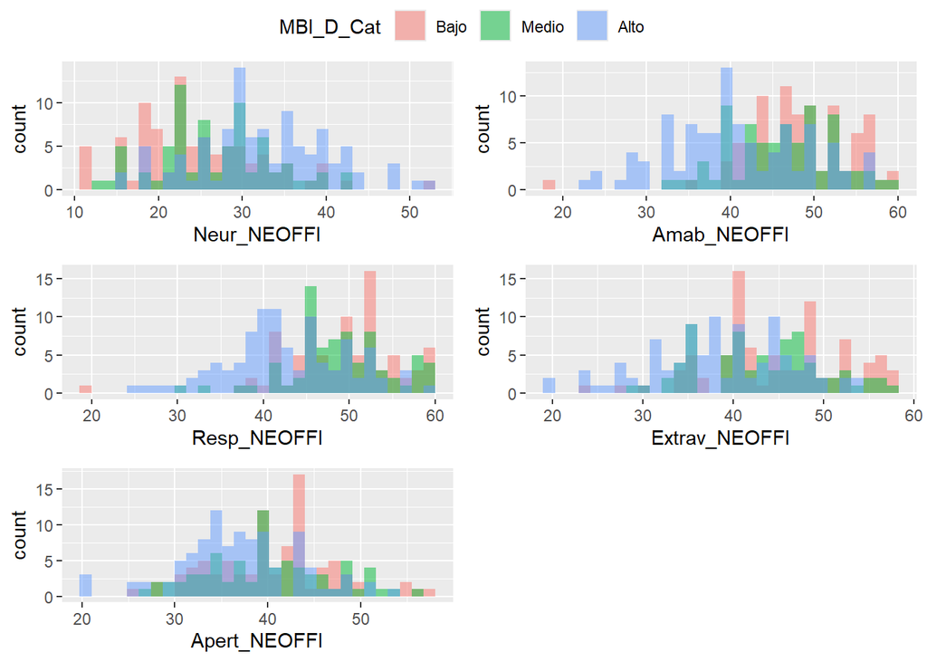

```r
#Ahora para MBI D

p1 <- ggplot(data = primaria, aes(x = Neur_NEOFFI, fill = MBI_D_Cat)) +
geom_histogram(position = "identity", alpha = 0.5)
p2 <- ggplot(data = primaria, aes(x = Amab_NEOFFI, fill = MBI_D_Cat)) +
geom_histogram(position = "identity", alpha = 0.5)
p3 <- ggplot(data = primaria, aes(x = Resp_NEOFFI, fill = MBI_D_Cat)) +
geom_histogram(position = "identity", alpha = 0.5)
p4 <- ggplot(data = primaria, aes(x = Extrav_NEOFFI, fill = MBI_D_Cat)) +
geom_histogram(position = "identity", alpha = 0.5)
p5 <- ggplot(data = primaria, aes(x = Apert_NEOFFI, fill = MBI_D_Cat)) +
geom_histogram(position = "identity", alpha = 0.5)

ggarrange(p1, p2, p3,p4,p5, nrow = 3,ncol = 2, common.legend = TRUE, top= "Clas. individual para el MBI_D")
```

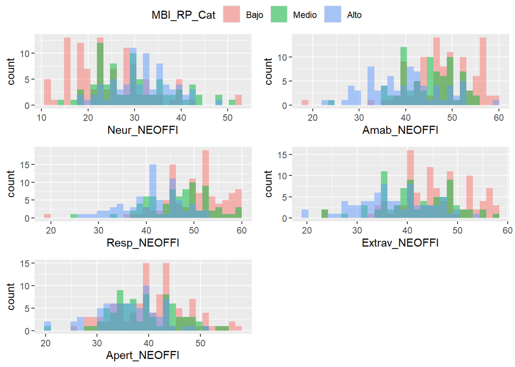

```r
#Finalmente para MBI RP
p1 <- ggplot(data = primaria, aes(x = Neur_NEOFFI, fill = MBI_RP_Cat)) +
geom_histogram(position = "identity", alpha = 0.5)
p2 <- ggplot(data = primaria, aes(x = Amab_NEOFFI, fill = MBI_RP_Cat)) +
geom_histogram(position = "identity", alpha = 0.5)
p3 <- ggplot(data = primaria, aes(x = Resp_NEOFFI, fill = MBI_RP_Cat)) +
geom_histogram(position = "identity", alpha = 0.5)
p4 <- ggplot(data = primaria, aes(x = Extrav_NEOFFI, fill = MBI_RP_Cat)) +
geom_histogram(position = "identity", alpha = 0.5)
p5 <- ggplot(data = primaria, aes(x = Apert_NEOFFI, fill = MBI_RP_Cat)) +
geom_histogram(position = "identity", alpha = 0.5)

ggarrange(p1, p2, p3,p4,p5, nrow = 3,ncol = 2, common.legend = TRUE, top= "Clas. individual para el MBI_RP")
```

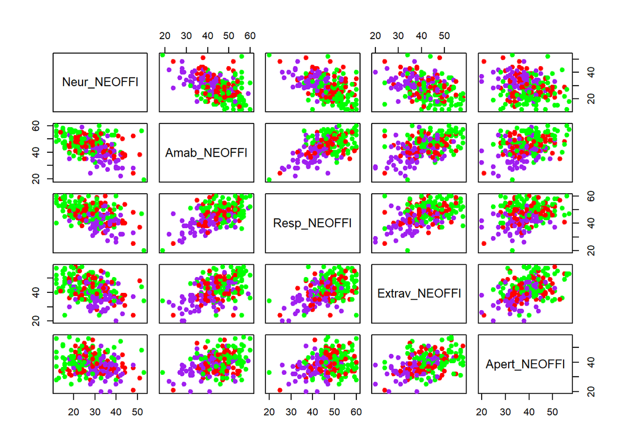

```r
pairs(x = primaria[, c("Neur_NEOFFI","Amab_NEOFFI","Resp_NEOFFI","Extrav_NEOFFI","Apert_NEOFFI")],
col = c("green", "red", "purple")[primaria$MBI_RP_Cat], pch = 19)
```

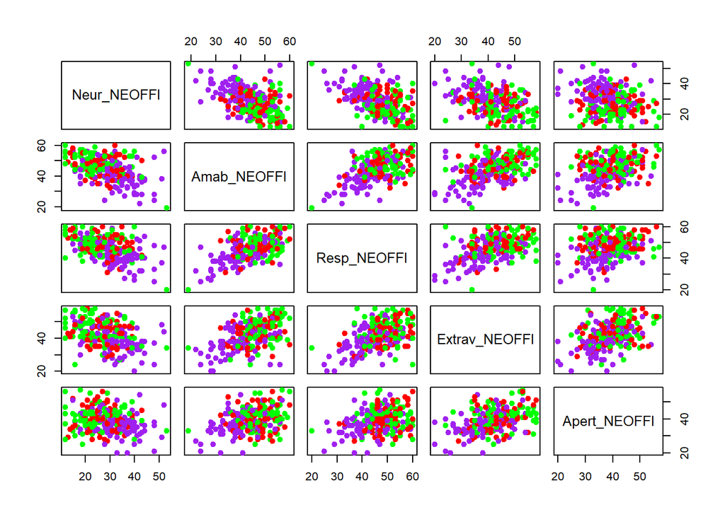

```r
pairs(x = primaria[, c("Neur_NEOFFI","Amab_NEOFFI","Resp_NEOFFI","Extrav_NEOFFI","Apert_NEOFFI")],
col = c("green", "red", "purple")[primaria$MBI_D_Cat], pch = 19)
```

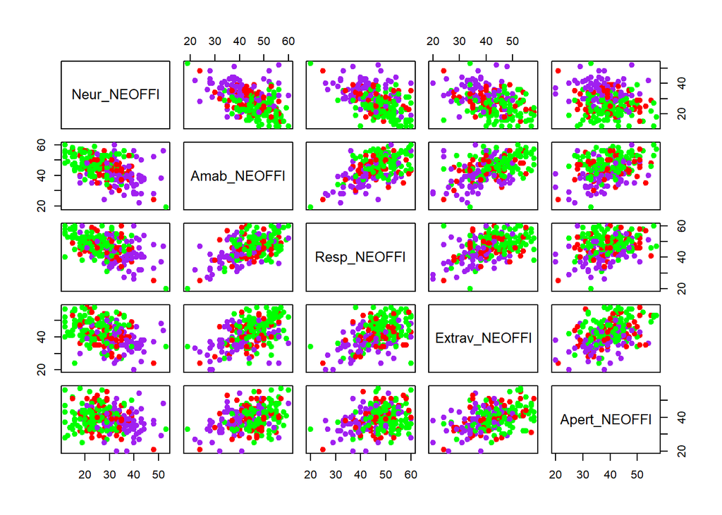

```r
pairs(x = primaria[, c("Neur_NEOFFI","Amab_NEOFFI","Resp_NEOFFI","Extrav_NEOFFI","Apert_NEOFFI")],
col = c("green", "red", "purple")[primaria$MBI_CE_Cat], pch = 19)
```

Tridimensional caso 1 para cansancio emocional

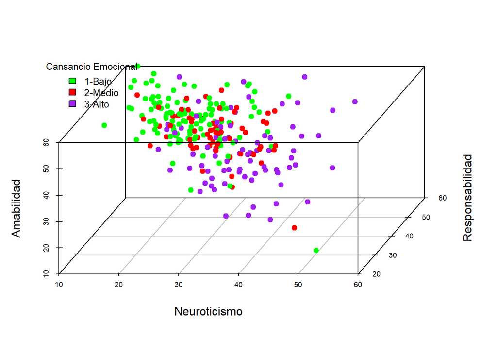

```r
scatterplot3d(Neur_NEOFFI, Resp_NEOFFI, Amab_NEOFFI,
color = c("green", "red", "purple")[MBI_CE_Cat], pch = 19,
grid = TRUE, xlab = "Neuroticismo", ylab = "Responsabilidad",
zlab = "Amabilidad", angle = 65, cex.axis = 0.6)
legend("topleft",
bty = "n", cex = 0.8,
title = "Cansancio Emocional",
c("1-Bajo", "2-Medio", "3-Alto"), fill = c("green", "red", "purple"))
```

Tridimensional caso 2 para cansancio emocional

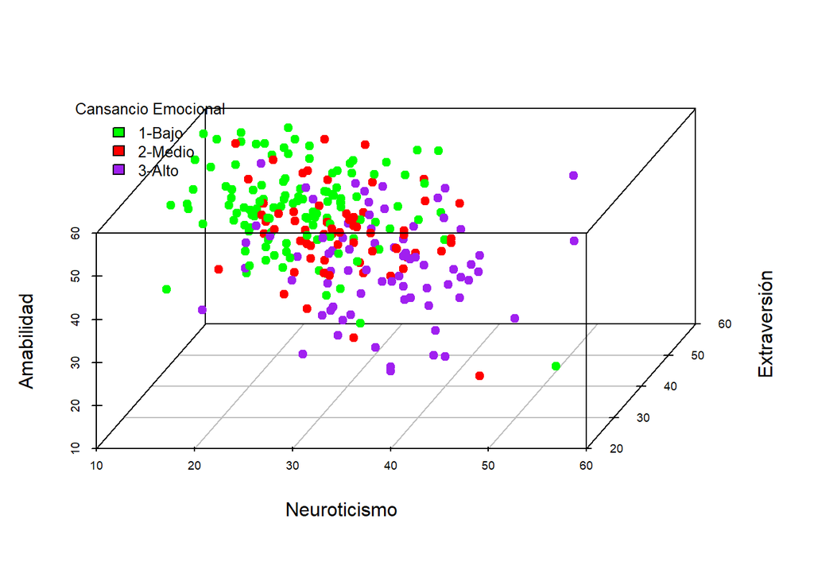

```r
scatterplot3d(Neur_NEOFFI, Extrav_NEOFFI, Amab_NEOFFI,
color = c("green", "red", "purple")[MBI_CE_Cat], pch = 19,
grid = TRUE, xlab = "Neuroticismo", ylab = "Extraversión",
zlab = "Amabilidad", angle = 65, cex.axis = 0.6)
legend("topleft",
bty = "n", cex = 0.8,
title = "Cansancio Emocional",
c("1-Bajo", "2-Medio", "3-Alto"), fill = c("green", "red", "purple"))
```

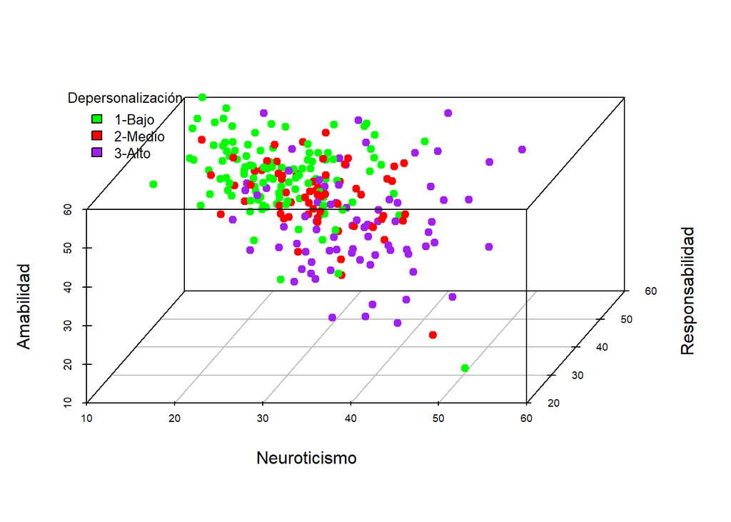

```r
scatterplot3d(Neur_NEOFFI, Resp_NEOFFI, Amab_NEOFFI,
color = c("green", "red", "purple")[MBI_CE_Cat], pch = 19,
grid = TRUE, xlab = "Neuroticismo", ylab = "Responsabilidad",
zlab = "Amabilidad", angle = 65, cex.axis = 0.6)
legend("topleft",
bty = "n", cex = 0.8,
title = "Depersonalización",
c("1-Bajo", "2-Medio", "3-Alto"), fill = c("green", "red", "purple"))
```

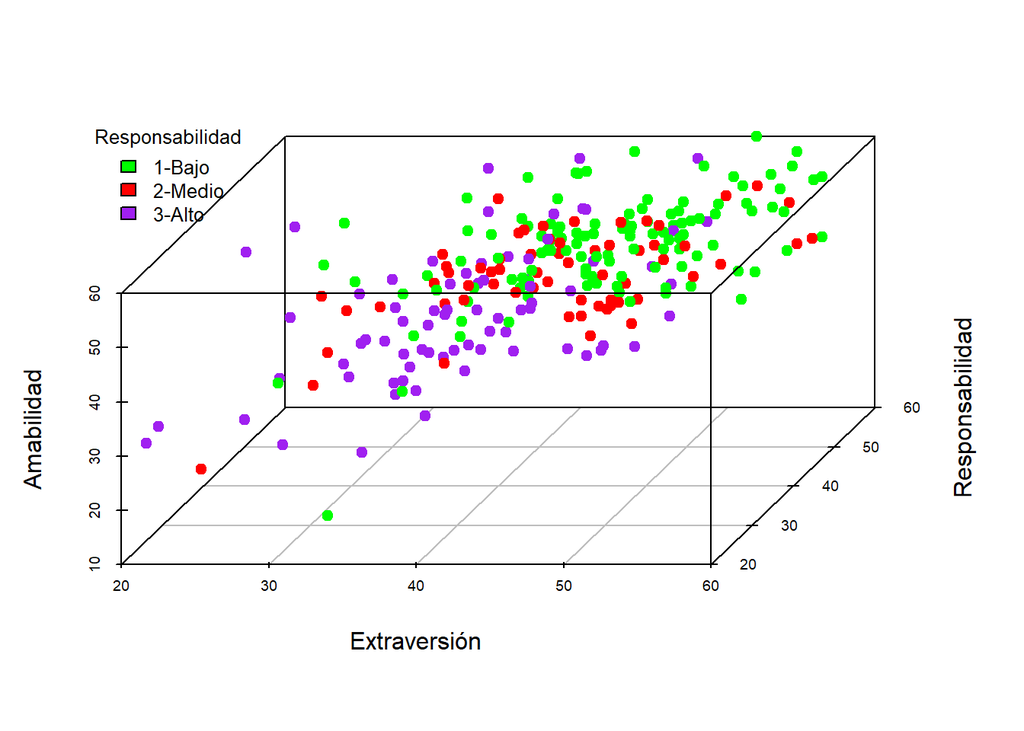

```r
scatterplot3d(Extrav_NEOFFI, Resp_NEOFFI, Amab_NEOFFI,
color = c("green", "red", "purple")[MBI_CE_Cat], pch = 19,
grid = TRUE, xlab = "Extraversión", ylab = "Responsabilidad",
zlab = "Amabilidad", angle = 65, cex.axis = 0.6)
legend("topleft",
bty = "n", cex = 0.8,
title = "Responsabilidad",
c("1-Bajo", "2-Medio", "3-Alto"), fill = c("green", "red", "purple"))
```

Vamos edu y yo a ver la normalidad

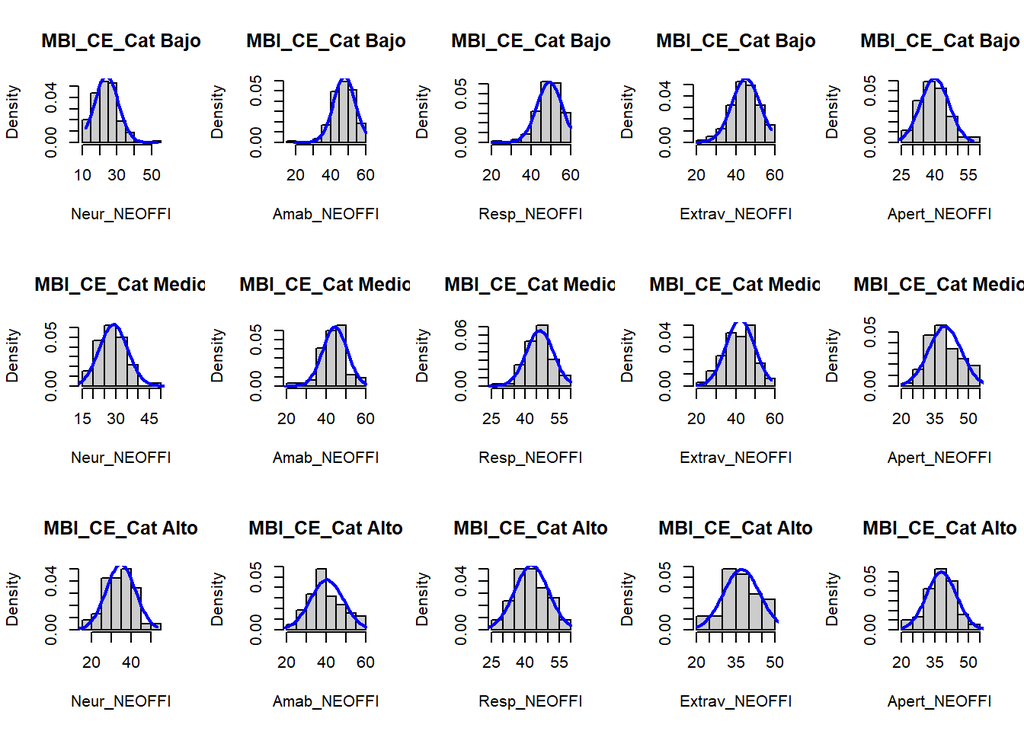

```r
par(mfcol = c(3, 5))
for (k in 4:8) {
j0 <- names(primaria)[k]
x0 <- seq(min(primaria[, k]), max(primaria[, k]), le = 50)
for (i in 1:3) {
i0 <- levels(primaria$MBI_CE_Cat)[i]
x <- primaria[primaria$MBI_CE_Cat == i0, j0]
hist(x, proba = T, col = grey(0.8), main = paste("MBI_CE_Cat", i0), xlab = j0)
lines(x0, dnorm(x0, mean(x), sd(x)), col = "blue", lwd = 2)
}
}
```

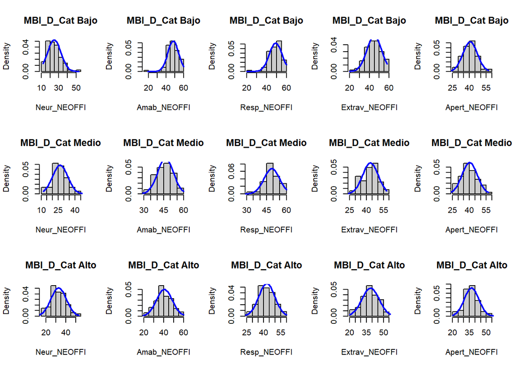

```r
par(mfcol = c(3, 5))
for (k in 4:8) {
j0 <- names(primaria)[k]
x0 <- seq(min(primaria[, k]), max(primaria[, k]), le = 50)
for (i in 1:3) {
i0 <- levels(primaria$MBI_D_Cat)[i]
x <- primaria[primaria$MBI_D_Cat == i0, j0]
hist(x, proba = T, col = grey(0.8), main = paste("MBI_D_Cat", i0), xlab = j0)
lines(x0, dnorm(x0, mean(x), sd(x)), col = "blue", lwd = 2)
}
}
```

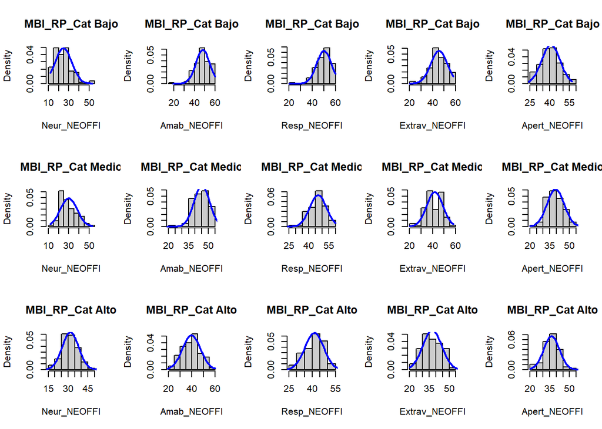

```r
par(mfcol = c(3, 5))
for (k in 4:8) {
j0 <- names(primaria)[k]
x0 <- seq(min(primaria[, k]), max(primaria[, k]), le = 50)
for (i in 1:3) {
i0 <- levels(primaria$MBI_RP_Cat)[i]
x <- primaria[primaria$MBI_RP_Cat == i0, j0]
hist(x, proba = T, col = grey(0.8), main = paste("MBI_RP_Cat", i0), xlab = j0)
lines(x0, dnorm(x0, mean(x), sd(x)), col = "blue", lwd = 2)
}
}
```

Una vez hemos visto que las variables de la personalidad siguen distribuciones normales por tanto podemos proseguir con el analisis discriminatorio.

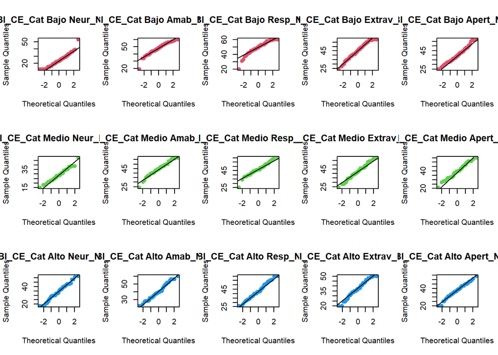

```r
par(mfcol = c(3, 5))
for (k in 4:8) {
j0 <- names(primaria)[k]
x0 <- seq(min(primaria[, k]), max(primaria[, k]), le = 50)
for (i in 1:3) {
i0 <- levels(primaria$MBI_CE_Cat)[i]
x <- primaria[primaria$MBI_CE_Cat == i0, j0]
qqnorm(x, main = paste("MBI_CE_Cat", i0, j0), pch = 19, col = i + 1)
qqline(x)
}
}
```

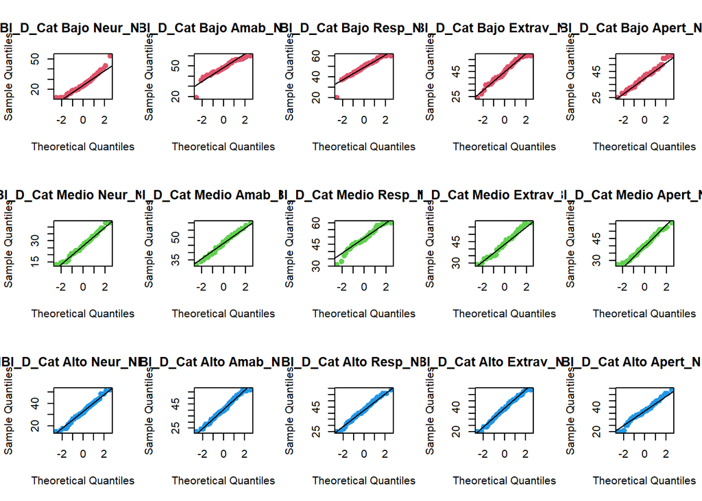

```r
par(mfcol = c(3, 5))
for (k in 4:8) {
j0 <- names(primaria)[k]
x0 <- seq(min(primaria[, k]), max(primaria[, k]), le = 50)
for (i in 1:3) {
i0 <- levels(primaria$MBI_D_Cat)[i]
x <- primaria[primaria$MBI_D_Cat == i0, j0]
qqnorm(x, main = paste("MBI_D_Cat", i0, j0), pch = 19, col = i + 1)
qqline(x)
}
}
```

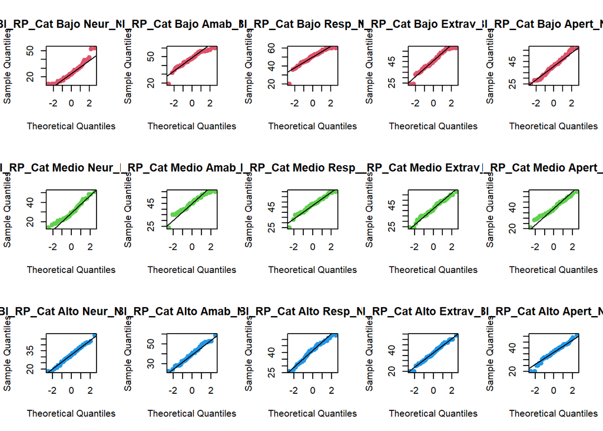

```r
par(mfcol = c(3, 5))
for (k in 4:8) {
j0 <- names(primaria)[k]
x0 <- seq(min(primaria[, k]), max(primaria[, k]), le = 50)
for (i in 1:3) {
i0 <- levels(primaria$MBI_RP_Cat)[i]
x <- primaria[primaria$MBI_RP_Cat == i0, j0]
qqnorm(x, main = paste("MBI_RP_Cat", i0, j0), pch = 19, col = i + 1)
qqline(x)
}
}
```

A mas lineal, mas normal

```r
primaria_tidy <- melt(primaria[,c(1:8)], value.name = "value")
aggregate( value ~ MBI_CE_Cat + variable, data = primaria_tidy,
FUN = function(x){shapiro.test(x)$p.value})
```

```
##    MBI_CE_Cat      variable        value
## 1        Bajo   Neur_NEOFFI 2.060080e-03
## 2       Medio   Neur_NEOFFI 5.582527e-01
## 3        Alto   Neur_NEOFFI 4.778061e-01
## 4        Bajo   Amab_NEOFFI 4.119856e-04
## 5       Medio   Amab_NEOFFI 2.556518e-01
## 6        Alto   Amab_NEOFFI 1.775878e-01
## 7        Bajo   Resp_NEOFFI 5.189019e-05
## 8       Medio   Resp_NEOFFI 1.345289e-01
## 9        Alto   Resp_NEOFFI 5.573210e-01
## 10       Bajo Extrav_NEOFFI 1.262173e-01
## 11      Medio Extrav_NEOFFI 7.685322e-01
## 12       Alto Extrav_NEOFFI 2.193247e-01
## 13       Bajo  Apert_NEOFFI 2.157279e-01
## 14      Medio  Apert_NEOFFI 5.527145e-01
## 15       Alto  Apert_NEOFFI 7.282000e-01
```

```r
primaria_tidy <- melt(primaria[,c(1:8)], value.name = "value")
aggregate( value ~ MBI_D_Cat + variable, data = primaria_tidy,
FUN = function(x){shapiro.test(x)$p.value})
```

```
##    MBI_D_Cat      variable        value
## 1       Bajo   Neur_NEOFFI 0.0072469056
## 2      Medio   Neur_NEOFFI 0.5122799105
## 3       Alto   Neur_NEOFFI 0.6117074801
## 4       Bajo   Amab_NEOFFI 0.0001022549
## 5      Medio   Amab_NEOFFI 0.8399452554
## 6       Alto   Amab_NEOFFI 0.3984799528
## 7       Bajo   Resp_NEOFFI 0.0003929164
## 8      Medio   Resp_NEOFFI 0.0362615344
## 9       Alto   Resp_NEOFFI 0.7609180042
## 10      Bajo Extrav_NEOFFI 0.0655305368
## 11     Medio Extrav_NEOFFI 0.2374897472
## 12      Alto Extrav_NEOFFI 0.4883106045
## 13      Bajo  Apert_NEOFFI 0.3563398348
## 14     Medio  Apert_NEOFFI 0.4883215606
## 15      Alto  Apert_NEOFFI 0.1801455862
```

```r
primaria_tidy <- melt(primaria[,c(1:8)], value.name = "value")
aggregate( value ~ MBI_RP_Cat + variable, data = primaria_tidy,
FUN = function(x){shapiro.test(x)$p.value})
```

```
##    MBI_RP_Cat      variable        value
## 1        Bajo   Neur_NEOFFI 3.635054e-04
## 2       Medio   Neur_NEOFFI 1.358315e-02
## 3        Alto   Neur_NEOFFI 9.268343e-01
## 4        Bajo   Amab_NEOFFI 3.927906e-04
## 5       Medio   Amab_NEOFFI 2.509855e-02
## 6        Alto   Amab_NEOFFI 7.629093e-01
## 7        Bajo   Resp_NEOFFI 3.666098e-05
## 8       Medio   Resp_NEOFFI 1.982848e-01
## 9        Alto   Resp_NEOFFI 1.502583e-01
## 10       Bajo Extrav_NEOFFI 1.931378e-02
## 11      Medio Extrav_NEOFFI 3.513178e-01
## 12       Alto Extrav_NEOFFI 8.442031e-01
## 13       Bajo  Apert_NEOFFI 5.006188e-01
## 14      Medio  Apert_NEOFFI 3.658831e-01
## 15       Alto  Apert_NEOFFI 3.364011e-01
```

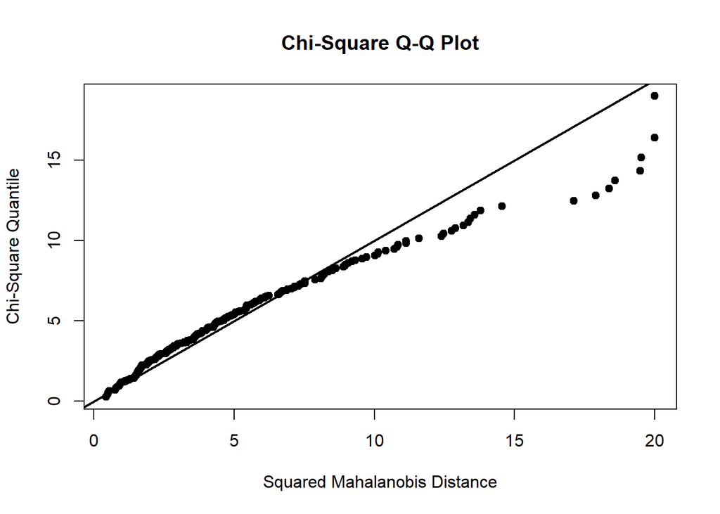

```r
#Hacemos analisis outliers aunque pensamos que no varia mucho
#outliers <- mvn(data = primaria[,c(4:8)], mvnTest = "hz", multivariateOutlierMethod = "quan")

#Test de Royston
royston_test <- mvn(data = primaria[,c(4:8)], mvnTest = "royston", multivariatePlot = "qq")
```

```r
royston_test$multivariateNormality
```

```
##      Test        H      p value MVN
## 1 Royston 28.70245 2.191613e-05  NO
```

```r
#Test de HZ
hz_test <- mvn(data = primaria[,c(4:8)], mvnTest = "hz")
hz_test$multivariateNormality
```

```
##            Test       HZ    p value MVN
## 1 Henze-Zirkler 1.109525 0.00157662  NO
```

```r
#Tenemos 5 predictores (las 5 de personalidad) asi que hacemos el Box M test
boxM(data = primaria[, 4:8], grouping = primaria[, 1])
```

```
##
##  Box's M-test for Homogeneity of Covariance Matrices
##
## data:  primaria[, 4:8]
## Chi-Sq (approx.) = 46.019, df = 30, p-value = 0.03095
```

```r
boxM(data = primaria[, 4:8], grouping = primaria[, 2])
```

```
##
##  Box's M-test for Homogeneity of Covariance Matrices
##
## data:  primaria[, 4:8]
## Chi-Sq (approx.) = 39.291, df = 30, p-value = 0.1193
```

```r
boxM(data = primaria[, 4:8], grouping = primaria[, 3])
```

```
##
##  Box's M-test for Homogeneity of Covariance Matrices
##
## data:  primaria[, 4:8]
## Chi-Sq (approx.) = 42.518, df = 30, p-value = 0.06458
```

Como todas son mayores que p=0.001, rechazamos la heterogeneidad de la varianza.

Aplicamos al fin el discriminante lineal

```r
modelo_ldaCE <- lda(formula = MBI_CE_Cat ~ Neur_NEOFFI + Amab_NEOFFI + Resp_NEOFFI+ Extrav_NEOFFI+ Apert_NEOFFI,data = primaria)
modelo_ldaCE
```

```
## Call:
## lda(MBI_CE_Cat ~ Neur_NEOFFI + Amab_NEOFFI + Resp_NEOFFI + Extrav_NEOFFI +
##     Apert_NEOFFI, data = primaria)
##
## Prior probabilities of groups:
##      Bajo     Medio      Alto
## 0.4573643 0.2480620 0.2945736
##
## Group means:
##       Neur_NEOFFI Amab_NEOFFI Resp_NEOFFI Extrav_NEOFFI Apert_NEOFFI
## Bajo     23.87288    47.80508    49.27966      45.04237     39.77966
## Medio    28.87500    44.35938    46.34375      42.15625     39.31250
## Alto     34.56579    40.23684    42.67105      37.17105     37.80263
##
## Coefficients of linear discriminants:
##                        LD1         LD2
## Neur_NEOFFI    0.099685593 -0.05939073
## Amab_NEOFFI   -0.040841365  0.04659324
## Resp_NEOFFI   -0.008240447  0.01355571
## Extrav_NEOFFI -0.053776508 -0.12511446
## Apert_NEOFFI   0.030048935 -0.05023194
##
## Proportion of trace:
##    LD1    LD2
## 0.9957 0.0043
```

```r
modelo_ldaD <- lda(formula = MBI_D_Cat ~ Neur_NEOFFI + Amab_NEOFFI + Resp_NEOFFI+ Extrav_NEOFFI+ Apert_NEOFFI,data = primaria)
modelo_ldaD
```

```
## Call:
## lda(MBI_D_Cat ~ Neur_NEOFFI + Amab_NEOFFI + Resp_NEOFFI + Extrav_NEOFFI +
##     Apert_NEOFFI, data = primaria)
##
## Prior probabilities of groups:
##      Bajo     Medio      Alto
## 0.3372093 0.2829457 0.3798450
##
## Group means:
##       Neur_NEOFFI Amab_NEOFFI Resp_NEOFFI Extrav_NEOFFI Apert_NEOFFI
## Bajo     24.75862    48.16092    49.12644      44.87356     40.63218
## Medio    26.71233    46.26027    48.94521      43.34247     40.19178
## Alto     32.53061    40.52041    42.62245      38.46939     36.87755
##
## Coefficients of linear discriminants:
##                       LD1         LD2
## Neur_NEOFFI    0.05403542 -0.05537977
## Amab_NEOFFI   -0.05858455  0.07919949
## Resp_NEOFFI   -0.04701543 -0.17186285
## Extrav_NEOFFI -0.01848702  0.04498592
## Apert_NEOFFI  -0.02557101 -0.03073817
##
## Proportion of trace:
##    LD1    LD2
## 0.9685 0.0315
```

```r
modelo_ldaRP <- lda(formula = MBI_RP_Cat ~ Neur_NEOFFI + Amab_NEOFFI + Resp_NEOFFI+ Extrav_NEOFFI+ Apert_NEOFFI,data = primaria)
modelo_ldaRP
```

```
## Call:
## lda(MBI_RP_Cat ~ Neur_NEOFFI + Amab_NEOFFI + Resp_NEOFFI + Extrav_NEOFFI +
##     Apert_NEOFFI, data = primaria)
##
## Prior probabilities of groups:
##      Bajo     Medio      Alto
## 0.4069767 0.3023256 0.2906977
##
## Group means:
##       Neur_NEOFFI Amab_NEOFFI Resp_NEOFFI Extrav_NEOFFI Apert_NEOFFI
## Bajo     24.68571    48.12381    50.14286      45.54286     40.80952
## Medio    29.79487    45.00000    46.92308      41.88462     39.37179
## Alto     31.68000    39.66667    41.32000      37.18667     36.36000
##
## Coefficients of linear discriminants:
##                        LD1         LD2
## Neur_NEOFFI    0.007641172 -0.14565094
## Amab_NEOFFI   -0.050243104 -0.04446965
## Resp_NEOFFI   -0.084272536 -0.07200723
## Extrav_NEOFFI -0.048410618  0.00804493
## Apert_NEOFFI  -0.012612291 -0.01433958
##
## Proportion of trace:
##   LD1   LD2
## 0.941 0.059
```

```r
modelo_ldaCECateg <- lda(formula = MBI_CE_Cat ~ Edad+Sexo+Antigüedad_profesión+Antigüedad_puesto+Turno_Cat+Guardias+Puesto_trabajo+Estado_Civil_Cat+Gestíon+Tiempo_gestión+Ocupó_gestión+Tiempo_ocupó_gestión,data = primaria)
modelo_ldaCECateg
```

```
## Call:
## lda(MBI_CE_Cat ~ Edad + Sexo + Antigüedad_profesión + Antigüedad_puesto +
##     Turno_Cat + Guardias + Puesto_trabajo + Estado_Civil_Cat +
##     Gestíon + Tiempo_gestión + Ocupó_gestión + Tiempo_ocupó_gestión,
##     data = primaria)
##
## Prior probabilities of groups:
##  Bajo Medio  Alto
## 0.452 0.256 0.292
##
## Group means:
##           Edad     Sexo2 Antigüedad_profesión Antigüedad_puesto
## Bajo  46.71681 0.5752212             281.4159          119.6637
## Medio 45.84375 0.4843750             270.4375          121.7656
## Alto  47.15068 0.6027397             298.6575          165.4658
##       Turno_CatRotatorio GuardiasSí Puesto_trabajoA. Primaria
## Bajo          0.13274336  0.6106195                 0.9646018
## Medio         0.07812500  0.6250000                 0.9375000
## Alto          0.06849315  0.7397260                 0.9726027
##       Estado_Civil_CatOtras situaciones  GestíonSí Tiempo_gestión
## Bajo                          0.2212389 0.09734513       7.433628
## Medio                         0.2031250 0.09375000       7.500000
## Alto                          0.2328767 0.06849315       6.082192
##       Ocupó_gestiónSí Tiempo_ocupó_gestión
## Bajo        0.2477876            16.115044
## Medio       0.1562500            21.000000
## Alto        0.1369863             8.945205
##
## Coefficients of linear discriminants:
##                                            LD1          LD2
## Edad                              -0.099891224  0.012624704
## Sexo2                              0.279377215  0.908079396
## Antigüedad_profesión               0.010726480  0.004073874
## Antigüedad_puesto                  0.006635467 -0.002638612
## Turno_CatRotatorio                -0.418275828  1.459356903
## GuardiasSí                         0.786867116  0.158053316
## Puesto_trabajoA. Primaria          0.253020762  1.590802114
## Estado_Civil_CatOtras situaciones  0.209726940  0.212812929
## GestíonSí                         -1.315072188 -0.607117229
## Tiempo_gestión                     0.011327668  0.013268695
## Ocupó_gestiónSí                   -0.881369681  2.343365987
## Tiempo_ocupó_gestión              -0.005174962 -0.021468205
##
## Proportion of trace:
##    LD1    LD2
## 0.6625 0.3375
```

```r
#OJO, ME ESTA DANDO UN ERROR AL METER COMO VARIABLE EL NUMERO DE HIJOS, ESTO SIGNIFICA QUE NO TIENE IMPORTANCIA EL NUMERO DE HIJOS RESPECTO A LA VARIABLE CE, YA QUE DICE QUE ES CONSTANTE.

modelo_ldaDCateg <- lda(formula = MBI_D_Cat ~ Edad+Sexo+Antigüedad_profesión+Antigüedad_puesto+Turno_Cat+Guardias+Puesto_trabajo+Estado_Civil_Cat+Gestíon+Tiempo_gestión+Ocupó_gestión+Tiempo_ocupó_gestión,data = primaria)
modelo_ldaDCateg
```

```
## Call:
## lda(MBI_D_Cat ~ Edad + Sexo + Antigüedad_profesión + Antigüedad_puesto +
##     Turno_Cat + Guardias + Puesto_trabajo + Estado_Civil_Cat +
##     Gestíon + Tiempo_gestión + Ocupó_gestión + Tiempo_ocupó_gestión,
##     data = primaria)
##
## Prior probabilities of groups:
##  Bajo Medio  Alto
## 0.332 0.284 0.384
##
## Group means:
##           Edad     Sexo2 Antigüedad_profesión Antigüedad_puesto
## Bajo  46.91566 0.6385542             280.9157          109.0000
## Medio 46.69014 0.6197183             285.3521          134.4789
## Alto  46.31250 0.4479167             284.7292          154.1562
##       Turno_CatRotatorio GuardiasSí Puesto_trabajoA. Primaria
## Bajo          0.09638554  0.5060241                  0.939759
## Medio         0.12676056  0.6901408                  0.971831
## Alto          0.08333333  0.7500000                  0.968750
##       Estado_Civil_CatOtras situaciones  GestíonSí Tiempo_gestión
## Bajo                          0.2168675 0.12048193       9.686747
## Medio                         0.1830986 0.11267606       8.281690
## Alto                          0.2500000 0.04166667       3.875000
##       Ocupó_gestiónSí Tiempo_ocupó_gestión
## Bajo        0.2168675            12.867470
## Medio       0.1971831            26.450704
## Alto        0.1666667             9.083333
##
## Coefficients of linear discriminants:
##                                             LD1           LD2
## Edad                              -0.0782247397  0.0107646169
## Sexo2                             -1.0441910441 -0.6303098137
## Antigüedad_profesión               0.0052608458 -0.0007069716
## Antigüedad_puesto                  0.0068133785 -0.0002046030
## Turno_CatRotatorio                -0.2516025695 -0.6941487314
## GuardiasSí                         0.8477512459 -1.0215476118
## Puesto_trabajoA. Primaria          0.1862530702 -1.0352338051
## Estado_Civil_CatOtras situaciones  0.3686590871  0.4251221679
## GestíonSí                         -1.3283501517 -2.5603893169
## Tiempo_gestión                     0.0006379670  0.0242188370
## Ocupó_gestiónSí                   -0.7356646944  1.8076069358
## Tiempo_ocupó_gestión              -0.0007404319 -0.0260146404
##
## Proportion of trace:
##    LD1    LD2
## 0.6744 0.3256
```

```r
#ME OCURRE LO MISMO EN ESTA CON EL NUM DE HIJOS

modelo_ldaRPCateg <- lda(formula = MBI_RP_Cat ~ Edad+Sexo+Antigüedad_profesión+Antigüedad_puesto+Turno_Cat+Guardias+Puesto_trabajo+Estado_Civil_Cat+Gestíon+Tiempo_gestión+Ocupó_gestión+Tiempo_ocupó_gestión,data = primaria)
modelo_ldaRPCateg
```

```
## Call:
## lda(MBI_RP_Cat ~ Edad + Sexo + Antigüedad_profesión + Antigüedad_puesto +
##     Turno_Cat + Guardias + Puesto_trabajo + Estado_Civil_Cat +
##     Gestíon + Tiempo_gestión + Ocupó_gestión + Tiempo_ocupó_gestión,
##     data = primaria)
##
## Prior probabilities of groups:
##  Bajo Medio  Alto
## 0.400 0.308 0.292
##
## Group means:
##           Edad     Sexo2 Antigüedad_profesión Antigüedad_puesto
## Bajo  46.73000 0.6100000             280.2800          114.7600
## Medio 46.32468 0.5064935             282.0519          146.0519
## Alto  46.78082 0.5479452             289.9178          146.1918
##       Turno_CatRotatorio GuardiasSí Puesto_trabajoA. Primaria
## Bajo          0.10000000  0.6800000                 0.9700000
## Medio         0.14285714  0.6233766                 0.9220779
## Alto          0.05479452  0.6438356                 0.9863014
##       Estado_Civil_CatOtras situaciones  GestíonSí Tiempo_gestión
## Bajo                          0.2100000 0.09000000       7.080000
## Medio                         0.2207792 0.12987013       9.662338
## Alto                          0.2328767 0.04109589       4.273973
##       Ocupó_gestiónSí Tiempo_ocupó_gestión
## Bajo        0.1900000            14.010000
## Medio       0.2597403            22.545455
## Alto        0.1232877             9.328767
##
## Coefficients of linear discriminants:
##                                            LD1           LD2
## Edad                               0.078114487  0.1535041528
## Sexo2                              0.671725315  0.7887283452
## Antigüedad_profesión              -0.002272227 -0.0096600210
## Antigüedad_puesto                 -0.003981215 -0.0076098733
## Turno_CatRotatorio                -0.871257387  0.8928038584
## GuardiasSí                         0.513237059  0.8490589200
## Puesto_trabajoA. Primaria          2.861048247 -0.1117452290
## Estado_Civil_CatOtras situaciones -0.113205809 -0.3061117508
## GestíonSí                         -2.801059529  2.5892547123
## Tiempo_gestión                     0.021353285 -0.0155132274
## Ocupó_gestiónSí                   -0.615759101  0.8871508622
## Tiempo_ocupó_gestión              -0.006833540  0.0006457259
##
## Proportion of trace:
##    LD1    LD2
## 0.5634 0.4366
```

```r
#Y EN ESTA IGUAL, POR ESO NO APARECE EN NINGUNA, PORQUE ME DA EL ERROR Y TENGO QUE QUITARLAS.
```

De esto obtenemos el modelo lineal de clasificacion discriminante tal que, dados los datos, nos dice a que grupo dentro del MBI, desconozco si lo que obtenemos de LD1 y LD2 son doos probabilidades lineales o una matriz, entiendo que una matriz.

Por ver el total por curiosidad

```r
modelo_ldaCETotal <- lda(formula = MBI_CE_Cat ~ Neur_NEOFFI+Amab_NEOFFI+Extrav_NEOFFI+Resp_NEOFFI+Apert_NEOFFI+Edad+Sexo+Antigüedad_profesión+Antigüedad_puesto+Turno_Cat+Guardias+Puesto_trabajo+Estado_Civil_Cat+Gestíon+Tiempo_gestión+Ocupó_gestión+Tiempo_ocupó_gestión,data = primaria)
modelo_ldaCETotal
```

```
## Call:
## lda(MBI_CE_Cat ~ Neur_NEOFFI + Amab_NEOFFI + Extrav_NEOFFI +
##     Resp_NEOFFI + Apert_NEOFFI + Edad + Sexo + Antigüedad_profesión +
##     Antigüedad_puesto + Turno_Cat + Guardias + Puesto_trabajo +
##     Estado_Civil_Cat + Gestíon + Tiempo_gestión + Ocupó_gestión +
##     Tiempo_ocupó_gestión, data = primaria)
##
## Prior probabilities of groups:
##  Bajo Medio  Alto
## 0.452 0.256 0.292
##
## Group means:
##       Neur_NEOFFI Amab_NEOFFI Extrav_NEOFFI Resp_NEOFFI Apert_NEOFFI     Edad
## Bajo     23.76106    47.76991      44.94690    49.38053     39.59292 46.71681
## Medio    28.87500    44.35938      42.15625    46.34375     39.31250 45.84375
## Alto     34.39726    39.73973      37.01370    42.42466     37.45205 47.15068
##           Sexo2 Antigüedad_profesión Antigüedad_puesto Turno_CatRotatorio
## Bajo  0.5752212             281.4159          119.6637         0.13274336
## Medio 0.4843750             270.4375          121.7656         0.07812500
## Alto  0.6027397             298.6575          165.4658         0.06849315
##       GuardiasSí Puesto_trabajoA. Primaria Estado_Civil_CatOtras situaciones
## Bajo   0.6106195                 0.9646018                         0.2212389
## Medio  0.6250000                 0.9375000                         0.2031250
## Alto   0.7397260                 0.9726027                         0.2328767
##        GestíonSí Tiempo_gestión Ocupó_gestiónSí Tiempo_ocupó_gestión
## Bajo  0.09734513       7.433628       0.2477876            16.115044
## Medio 0.09375000       7.500000       0.1562500            21.000000
## Alto  0.06849315       6.082192       0.1369863             8.945205
##
## Coefficients of linear discriminants:
##                                             LD1          LD2
## Neur_NEOFFI                        0.0891869689 -0.034489690
## Amab_NEOFFI                       -0.0468007782 -0.007447456
## Extrav_NEOFFI                     -0.0504584315 -0.031581022
## Resp_NEOFFI                       -0.0038782593  0.021258477
## Apert_NEOFFI                       0.0275260955 -0.014504728
## Edad                              -0.0216630720 -0.032800665
## Sexo2                              0.1241297080  0.913413905
## Antigüedad_profesión               0.0014679332  0.007809508
## Antigüedad_puesto                  0.0024890932  0.001242192
## Turno_CatRotatorio                -0.2070614085  1.050487901
## GuardiasSí                         0.3906038128  0.479859432
## Puesto_trabajoA. Primaria         -0.1864279448  1.370545764
## Estado_Civil_CatOtras situaciones -0.1416137725  0.265265285
## GestíonSí                          0.0918526692 -1.072686771
## Tiempo_gestión                     0.0008370994  0.015971292
## Ocupó_gestiónSí                   -0.5571846002  1.598363790
## Tiempo_ocupó_gestión              -0.0002236143 -0.021307389
##
## Proportion of trace:
##    LD1    LD2
## 0.9053 0.0947
```

```r
# Extraer la matriz de coeficientes (scaling) y convertirla en data.frame
scaling_df <- as.data.frame(modelo_ldaCETotal$scaling)

# Añadir los nombres de las variables como columna
scaling_df$Variable <- rownames(scaling_df)

# Reordenar el data.frame por los valores de LD1 de mayor a menor
scaling_ordered <- scaling_df[order(scaling_df$LD1, decreasing = TRUE), ]

# Mostrar la tabla ordenada
print(scaling_ordered)
```

```
##                                             LD1          LD2
## GuardiasSí                         0.3906038128  0.479859432
## Sexo2                              0.1241297080  0.913413905
## GestíonSí                          0.0918526692 -1.072686771
## Neur_NEOFFI                        0.0891869689 -0.034489690
## Apert_NEOFFI                       0.0275260955 -0.014504728
## Antigüedad_puesto                  0.0024890932  0.001242192
## Antigüedad_profesión               0.0014679332  0.007809508
## Tiempo_gestión                     0.0008370994  0.015971292
## Tiempo_ocupó_gestión              -0.0002236143 -0.021307389
## Resp_NEOFFI                       -0.0038782593  0.021258477
## Edad                              -0.0216630720 -0.032800665
## Amab_NEOFFI                       -0.0468007782 -0.007447456
## Extrav_NEOFFI                     -0.0504584315 -0.031581022
## Estado_Civil_CatOtras situaciones -0.1416137725  0.265265285
## Puesto_trabajoA. Primaria         -0.1864279448  1.370545764
## Turno_CatRotatorio                -0.2070614085  1.050487901
## Ocupó_gestiónSí                   -0.5571846002  1.598363790
##                                                            Variable
## GuardiasSí                                               GuardiasSí
## Sexo2                                                         Sexo2
## GestíonSí                                                 GestíonSí
## Neur_NEOFFI                                             Neur_NEOFFI
## Apert_NEOFFI                                           Apert_NEOFFI
## Antigüedad_puesto                                 Antigüedad_puesto
## Antigüedad_profesión                           Antigüedad_profesión
## Tiempo_gestión                                       Tiempo_gestión
## Tiempo_ocupó_gestión                           Tiempo_ocupó_gestión
## Resp_NEOFFI                                             Resp_NEOFFI
## Edad                                                           Edad
## Amab_NEOFFI                                             Amab_NEOFFI
## Extrav_NEOFFI                                         Extrav_NEOFFI
## Estado_Civil_CatOtras situaciones Estado_Civil_CatOtras situaciones
## Puesto_trabajoA. Primaria                 Puesto_trabajoA. Primaria
## Turno_CatRotatorio                               Turno_CatRotatorio
## Ocupó_gestiónSí                                     Ocupó_gestiónSí
```

```r
modelo_ldaDTotal <- lda(formula = MBI_D_Cat ~ Neur_NEOFFI+Amab_NEOFFI+Extrav_NEOFFI+Resp_NEOFFI+Apert_NEOFFI+Edad+Sexo+Antigüedad_profesión+Antigüedad_puesto+Turno_Cat+Guardias+Puesto_trabajo+Estado_Civil_Cat+Gestíon+Tiempo_gestión+Ocupó_gestión+Tiempo_ocupó_gestión,data = primaria)

# Extraer la matriz de coeficientes (scaling) y convertirla en data.frame
scaling_df <- as.data.frame(modelo_ldaDTotal$scaling)

# Añadir los nombres de las variables como columna
scaling_df$Variable <- rownames(scaling_df)

# Reordenar el data.frame por los valores de LD1 de mayor a menor
scaling_ordered <- scaling_df[order(scaling_df$LD1, decreasing = TRUE), ]

# Mostrar la tabla ordenada
print(scaling_ordered)
```

```
##                                             LD1          LD2
## GuardiasSí                         0.5035363636 -1.128938567
## Estado_Civil_CatOtras situaciones  0.0614866578  0.282291450
## Neur_NEOFFI                        0.0419876284 -0.004070171
## Antigüedad_puesto                  0.0028825578 -0.002261217
## Antigüedad_profesión               0.0016824084 -0.001704269
## Tiempo_gestión                    -0.0002546594  0.022283694
## Tiempo_ocupó_gestión              -0.0026272092 -0.023503522
## Turno_CatRotatorio                -0.0143861059 -0.448925134
## Apert_NEOFFI                      -0.0203791484 -0.020541151
## Extrav_NEOFFI                     -0.0210127914 -0.003021449
## Edad                              -0.0336959213  0.028187457
## Resp_NEOFFI                       -0.0387984210 -0.037860093
## Amab_NEOFFI                       -0.0511898738  0.027095798
## Ocupó_gestiónSí                   -0.1603505455  1.828733842
## Puesto_trabajoA. Primaria         -0.2699881174 -1.152596893
## GestíonSí                         -0.5465611550 -2.032174576
## Sexo2                             -0.6420540770 -0.346109335
##                                                            Variable
## GuardiasSí                                               GuardiasSí
## Estado_Civil_CatOtras situaciones Estado_Civil_CatOtras situaciones
## Neur_NEOFFI                                             Neur_NEOFFI
## Antigüedad_puesto                                 Antigüedad_puesto
## Antigüedad_profesión                           Antigüedad_profesión
## Tiempo_gestión                                       Tiempo_gestión
## Tiempo_ocupó_gestión                           Tiempo_ocupó_gestión
## Turno_CatRotatorio                               Turno_CatRotatorio
## Apert_NEOFFI                                           Apert_NEOFFI
## Extrav_NEOFFI                                         Extrav_NEOFFI
## Edad                                                           Edad
## Resp_NEOFFI                                             Resp_NEOFFI
## Amab_NEOFFI                                             Amab_NEOFFI
## Ocupó_gestiónSí                                     Ocupó_gestiónSí
## Puesto_trabajoA. Primaria                 Puesto_trabajoA. Primaria
## GestíonSí                                                 GestíonSí
## Sexo2                                                         Sexo2
```

```r
modelo_ldaRPTotal <- lda(formula = MBI_RP_Cat ~ Neur_NEOFFI+Amab_NEOFFI+Extrav_NEOFFI+Resp_NEOFFI+Apert_NEOFFI+Edad+Sexo+Antigüedad_profesión+Antigüedad_puesto+Turno_Cat+Guardias+Puesto_trabajo+Estado_Civil_Cat+Gestíon+Tiempo_gestión+Ocupó_gestión+Tiempo_ocupó_gestión,data = primaria)

# Extraer la matriz de coeficientes (scaling) y convertirla en data.frame
scaling_df <- as.data.frame(modelo_ldaRPTotal$scaling)

# Añadir los nombres de las variables como columna
scaling_df$Variable <- rownames(scaling_df)

# Reordenar el data.frame por los valores de LD1 de mayor a menor
scaling_ordered <- scaling_df[order(scaling_df$LD1, decreasing = TRUE), ]

# Mostrar la tabla ordenada
print(scaling_ordered)
```

```
##                                             LD1           LD2
## Neur_NEOFFI                        0.0145979657 -9.533777e-02
## Tiempo_gestión                     0.0046314404  1.731686e-02
## Antigüedad_profesión               0.0021254185  4.464528e-05
## Antigüedad_puesto                  0.0016145948 -3.047937e-03
## Tiempo_ocupó_gestión               0.0006655468 -4.064917e-03
## Apert_NEOFFI                      -0.0078801913 -2.707981e-02
## Turno_CatRotatorio                -0.0174322416 -7.829026e-01
## Amab_NEOFFI                       -0.0400263418 -5.461835e-02
## Edad                              -0.0482489031  4.592880e-02
## Extrav_NEOFFI                     -0.0509957347  1.911781e-02
## Resp_NEOFFI                       -0.0792845734 -3.244685e-02
## Estado_Civil_CatOtras situaciones -0.1346039350 -1.337916e-01
## Sexo2                             -0.1827339347  6.715625e-01
## Puesto_trabajoA. Primaria         -0.2504135805  2.073809e+00
## Ocupó_gestiónSí                   -0.2557069339 -6.164551e-01
## GuardiasSí                        -0.3734485971  4.652800e-01
## GestíonSí                         -0.5872806000 -2.307003e+00
##                                                            Variable
## Neur_NEOFFI                                             Neur_NEOFFI
## Tiempo_gestión                                       Tiempo_gestión
## Antigüedad_profesión                           Antigüedad_profesión
## Antigüedad_puesto                                 Antigüedad_puesto
## Tiempo_ocupó_gestión                           Tiempo_ocupó_gestión
## Apert_NEOFFI                                           Apert_NEOFFI
## Turno_CatRotatorio                               Turno_CatRotatorio
## Amab_NEOFFI                                             Amab_NEOFFI
## Edad                                                           Edad
## Extrav_NEOFFI                                         Extrav_NEOFFI
## Resp_NEOFFI                                             Resp_NEOFFI
## Estado_Civil_CatOtras situaciones Estado_Civil_CatOtras situaciones
## Sexo2                                                         Sexo2
## Puesto_trabajoA. Primaria                 Puesto_trabajoA. Primaria
## Ocupó_gestiónSí                                     Ocupó_gestiónSí
## GuardiasSí                                               GuardiasSí
## GestíonSí                                                 GestíonSí
```

Volvemos a lo que estabamos haciendo

```r
modelo_ldaCE <- lda(formula = MBI_CE_Cat ~ Neur_NEOFFI + Amab_NEOFFI + Resp_NEOFFI+ Extrav_NEOFFI+ Apert_NEOFFI,data = primaria)
modelo_ldaCE
```

```
## Call:
## lda(MBI_CE_Cat ~ Neur_NEOFFI + Amab_NEOFFI + Resp_NEOFFI + Extrav_NEOFFI +
##     Apert_NEOFFI, data = primaria)
##
## Prior probabilities of groups:
##      Bajo     Medio      Alto
## 0.4573643 0.2480620 0.2945736
##
## Group means:
##       Neur_NEOFFI Amab_NEOFFI Resp_NEOFFI Extrav_NEOFFI Apert_NEOFFI
## Bajo     23.87288    47.80508    49.27966      45.04237     39.77966
## Medio    28.87500    44.35938    46.34375      42.15625     39.31250
## Alto     34.56579    40.23684    42.67105      37.17105     37.80263
##
## Coefficients of linear discriminants:
##                        LD1         LD2
## Neur_NEOFFI    0.099685593 -0.05939073
## Amab_NEOFFI   -0.040841365  0.04659324
## Resp_NEOFFI   -0.008240447  0.01355571
## Extrav_NEOFFI -0.053776508 -0.12511446
## Apert_NEOFFI   0.030048935 -0.05023194
##
## Proportion of trace:
##    LD1    LD2
## 0.9957 0.0043
```

```r
modelo_ldaD <- lda(formula = MBI_D_Cat ~ Neur_NEOFFI + Amab_NEOFFI + Resp_NEOFFI+ Extrav_NEOFFI+ Apert_NEOFFI,data = primaria)
modelo_ldaD
```

```
## Call:
## lda(MBI_D_Cat ~ Neur_NEOFFI + Amab_NEOFFI + Resp_NEOFFI + Extrav_NEOFFI +
##     Apert_NEOFFI, data = primaria)
##
## Prior probabilities of groups:
##      Bajo     Medio      Alto
## 0.3372093 0.2829457 0.3798450
##
## Group means:
##       Neur_NEOFFI Amab_NEOFFI Resp_NEOFFI Extrav_NEOFFI Apert_NEOFFI
## Bajo     24.75862    48.16092    49.12644      44.87356     40.63218
## Medio    26.71233    46.26027    48.94521      43.34247     40.19178
## Alto     32.53061    40.52041    42.62245      38.46939     36.87755
##
## Coefficients of linear discriminants:
##                       LD1         LD2
## Neur_NEOFFI    0.05403542 -0.05537977
## Amab_NEOFFI   -0.05858455  0.07919949
## Resp_NEOFFI   -0.04701543 -0.17186285
## Extrav_NEOFFI -0.01848702  0.04498592
## Apert_NEOFFI  -0.02557101 -0.03073817
##
## Proportion of trace:
##    LD1    LD2
## 0.9685 0.0315
```

```r
modelo_ldaRP <- lda(formula = MBI_RP_Cat ~ Neur_NEOFFI + Amab_NEOFFI + Resp_NEOFFI+ Extrav_NEOFFI+ Apert_NEOFFI,data = primaria)
modelo_ldaRP
```

```
## Call:
## lda(MBI_RP_Cat ~ Neur_NEOFFI + Amab_NEOFFI + Resp_NEOFFI + Extrav_NEOFFI +
##     Apert_NEOFFI, data = primaria)
##
## Prior probabilities of groups:
##      Bajo     Medio      Alto
## 0.4069767 0.3023256 0.2906977
##
## Group means:
##       Neur_NEOFFI Amab_NEOFFI Resp_NEOFFI Extrav_NEOFFI Apert_NEOFFI
## Bajo     24.68571    48.12381    50.14286      45.54286     40.80952
## Medio    29.79487    45.00000    46.92308      41.88462     39.37179
## Alto     31.68000    39.66667    41.32000      37.18667     36.36000
##
## Coefficients of linear discriminants:
##                        LD1         LD2
## Neur_NEOFFI    0.007641172 -0.14565094
## Amab_NEOFFI   -0.050243104 -0.04446965
## Resp_NEOFFI   -0.084272536 -0.07200723
## Extrav_NEOFFI -0.048410618  0.00804493
## Apert_NEOFFI  -0.012612291 -0.01433958
##
## Proportion of trace:
##   LD1   LD2
## 0.941 0.059
```

```r
nuev_obs<-data.frame(Neur_NEOFFI=42, Amab_NEOFFI=37,Resp_NEOFFI=85,Extrav_NEOFFI=12,Apert_NEOFFI=52)
predict(object=modelo_ldaCE,newdata=nuev_obs)
```

```
## $class
## [1] Alto
## Levels: Bajo Medio Alto
##
## $posterior
##          Bajo     Medio      Alto
## 1 0.004695334 0.0376679 0.9576368
##
## $x
##        LD1      LD2
## 1 3.370165 2.450393
```

```r
predict(object=modelo_ldaD,newdata=nuev_obs)
```

```
## $class
## [1] Medio
## Levels: Bajo Medio Alto
##
## $posterior
##         Bajo     Medio       Alto
## 1 0.06363458 0.8468886 0.08947683
##
## $x
##          LD1       LD2
## 1 -0.3861805 -9.717969
```

```r
predict(object=modelo_ldaRP,newdata=nuev_obs)
```

```
## $class
## [1] Medio
## Levels: Bajo Medio Alto
##
## $posterior
##        Bajo     Medio       Alto
## 1 0.3046416 0.6799371 0.01542135
##
## $x
##         LD1       LD2
## 1 -1.453027 -4.848778
```

De modo que nuestro sujeto inventado tendria un CE Alto y unos D y RP medios Deberiamos haber utilizado un training set y un test set por lados distintos, pero realmente es igual.

Siguiendo con el tratamiento veamos la matriz de confusion: Nos da la eficiencia(predichos/verdaderos) y pureza (predichos/total predicciones) (esto ultimo es, si buscasemos Altos, seria predichos altos/predichos altos medios y bajos).

```r
pred <- predict(modelo_ldaCE, dimen = 2)
confusionmatrix(primaria$MBI_CE_Cat, pred$class)
```

```
##       new Alto new Bajo new Medio
## Alto        56       19         1
## Bajo        11      105         2
## Medio       24       38         2
```

```r
training_errorCE<-mean(primaria$MBI_CE_Cat != pred$class) * 100
paste("training_errorCE=", training_errorCE, "%")
```

```
## [1] "training_errorCE= 36.8217054263566 %"
```

```r
pred <- predict(modelo_ldaD, dimen = 2)
confusionmatrix(primaria$MBI_D_Cat, pred$class)
```

```
##       new Alto new Bajo new Medio
## Alto        72       22         4
## Bajo        15       54        18
## Medio       23       36        14
```

```r
training_errorD<-mean(primaria$MBI_D_Cat != pred$class) * 100
paste("training_errorD=", training_errorD, "%")
```

```
## [1] "training_errorD= 45.7364341085271 %"
```

```r
pred <- predict(modelo_ldaRP, dimen = 2)
confusionmatrix(primaria$MBI_RP_Cat, pred$class)
```

```
##       new Alto new Bajo new Medio
## Alto        45       16        14
## Bajo         8       85        12
## Medio       17       45        16
```

```r
training_errorRP<-mean(primaria$MBI_RP_Cat != pred$class) * 100
paste("training_errorRP=", training_errorRP, "%")
```

```
## [1] "training_errorRP= 43.4108527131783 %"
```

```r
pred <- predict(modelo_ldaCETotal, dimen = 2)
confusionmatrix(primaria$MBI_CE_Cat[1:250], pred$class)
```

```
##       new Alto new Bajo new Medio
## Alto        26       35        11
## Bajo        27       72        18
## Medio       14       34        13
```

```r
training_errorCE<-mean(primaria$MBI_CE_Cat != pred$class) * 100
paste("training_errorCE=", training_errorCE, "%")
```

```
## [1] "training_errorCE= 56.9767441860465 %"
```

```r
pred <- predict(modelo_ldaDTotal, dimen = 2)
confusionmatrix(primaria$MBI_D_Cat[1:250], pred$class)
```

```
##       new Alto new Bajo new Medio
## Alto        50       26        18
## Bajo        28       38        19
## Medio       21       34        16
```

```r
training_errorD<-mean(primaria$MBI_D_Cat != pred$class) * 100
paste("training_errorD=", training_errorD, "%")
```

```
## [1] "training_errorD= 58.9147286821705 %"
```

```r
pred <- predict(modelo_ldaRPTotal, dimen = 2)
confusionmatrix(primaria$MBI_RP_Cat[1:250], pred$class)
```

```
##       new Alto new Bajo new Medio
## Alto        23       33        16
## Bajo        32       52        19
## Medio       18       34        23
```

```r
training_errorRP<-mean(primaria$MBI_RP_Cat != pred$class) * 100
paste("training_errorRP=", training_errorRP, "%")
```

```
## [1] "training_errorRP= 61.6279069767442 %"
```

A pesar de haber hecho a parte los totales para ver si las variables categoricas influyen, estos modelos tienen un error mucho mayor que el 50%, entonces no deberiamos de hacerles caso para nada.

Vemos que el modelo lda se equivoca una barbaridad.

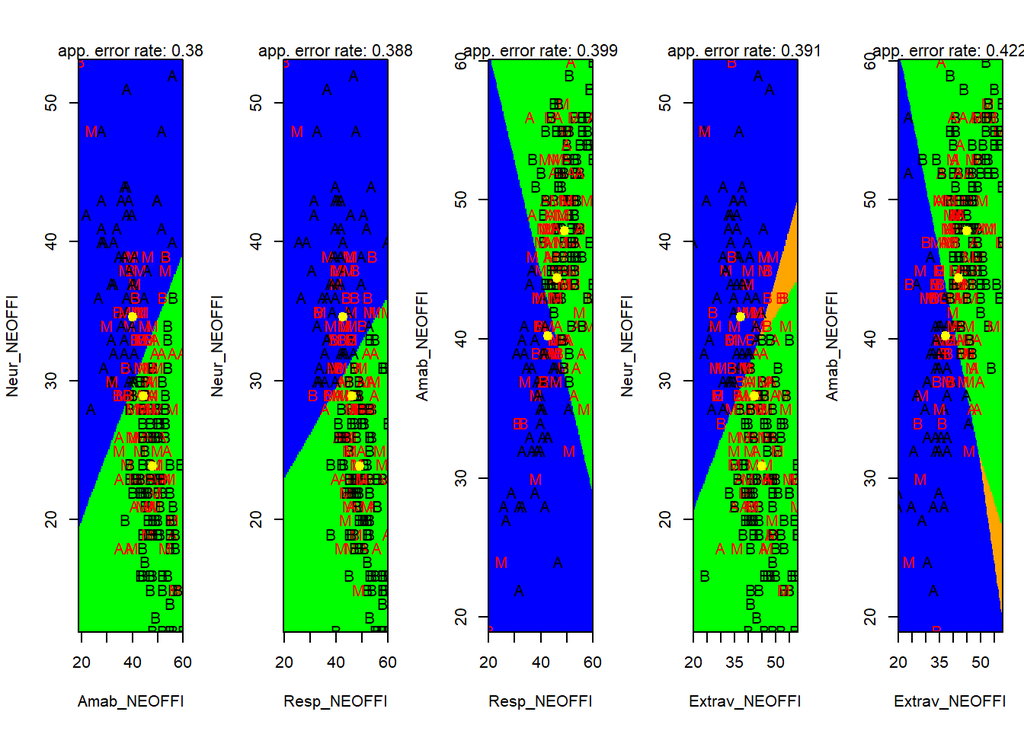

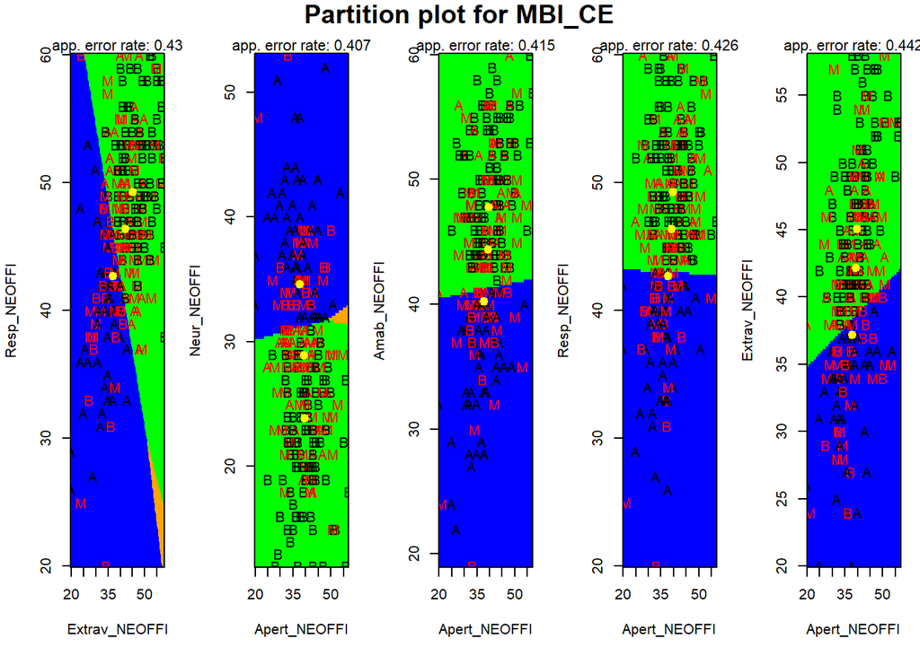

```r
partimat(MBI_CE_Cat ~Neur_NEOFFI + Amab_NEOFFI + Resp_NEOFFI+ Extrav_NEOFFI+ Apert_NEOFFI ,
data = primaria, method = "lda", prec = 200,
image.colors = c("green", "orange","blue"),
col.mean = "yellow",nplots.vert =1, nplots.hor=5, main= "Partition plot for MBI_CE")
```

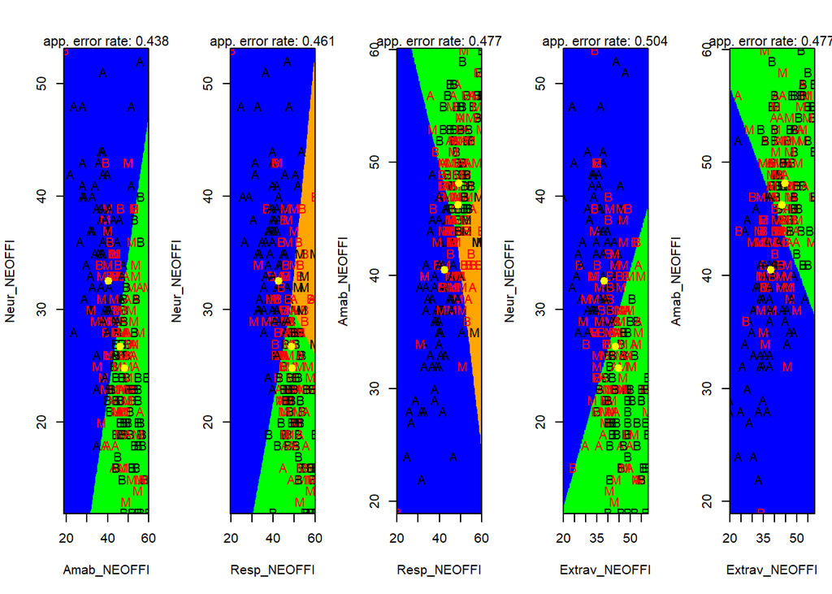

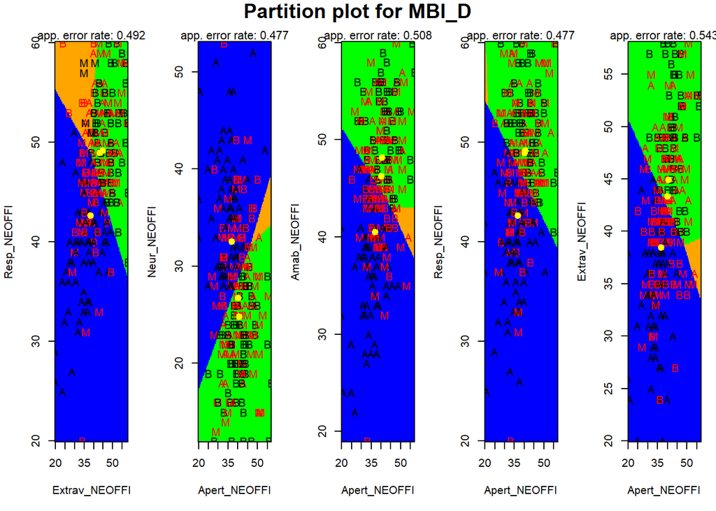

```r
partimat(MBI_D_Cat ~Neur_NEOFFI + Amab_NEOFFI + Resp_NEOFFI+ Extrav_NEOFFI+ Apert_NEOFFI ,
data = primaria, method = "lda", prec = 200,
image.colors = c("green", "orange","blue"),
col.mean = "yellow",nplots.vert =1, nplots.hor=5,main= "Partition plot for MBI_D")
```

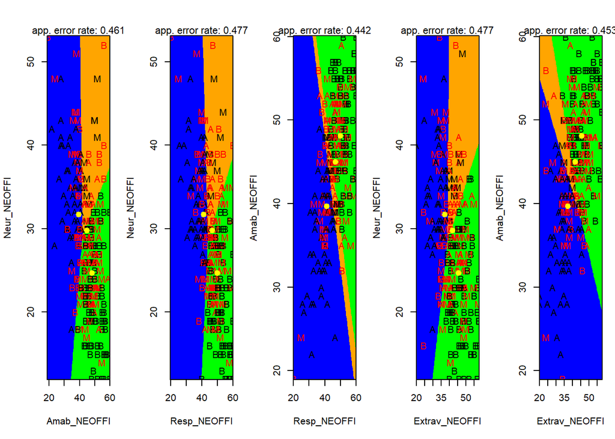

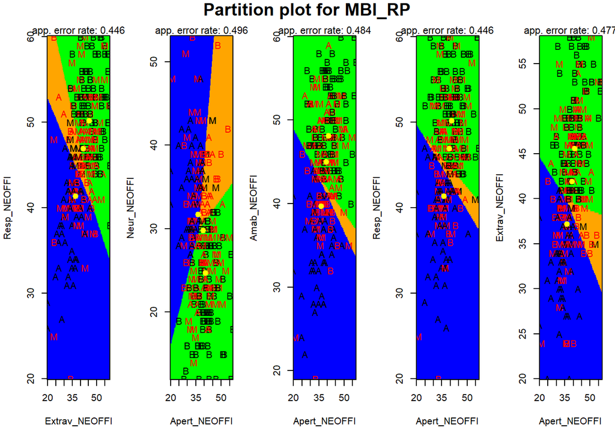

```r
partimat(MBI_RP_Cat ~Neur_NEOFFI + Amab_NEOFFI + Resp_NEOFFI+ Extrav_NEOFFI+ Apert_NEOFFI ,
data = primaria, method = "lda", prec = 200,
image.colors = c("green", "orange","blue"),
col.mean = "yellow",nplots.vert =1, nplots.hor=5,main= "Partition plot for MBI_RP")
```

Las dos primeras son para el CE, las dos siguientes para el D y las dos ultimas para el RP